# Code - From little things, big things grow: using applied nucleation to restore marine forests

```r
check_model(glm_S)
```

```
## `check_outliers()` does not yet support models of class `glmmTMB`.
```

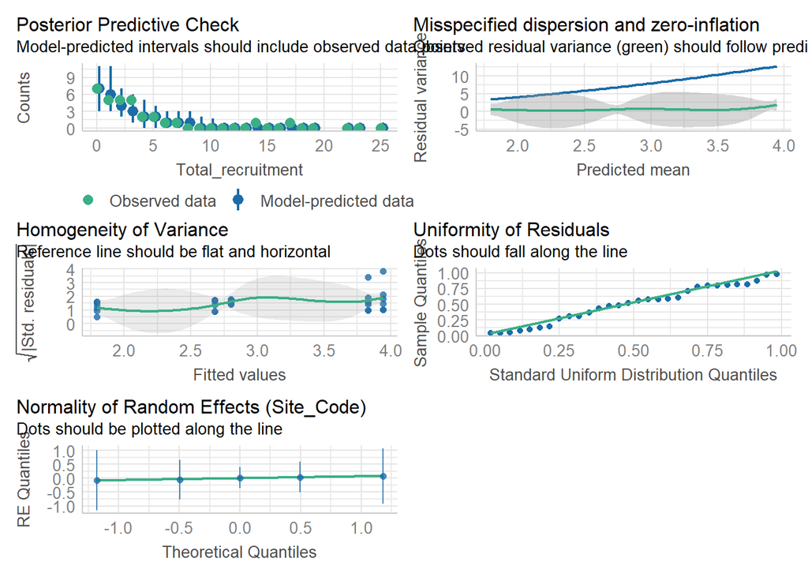

Plot relationships

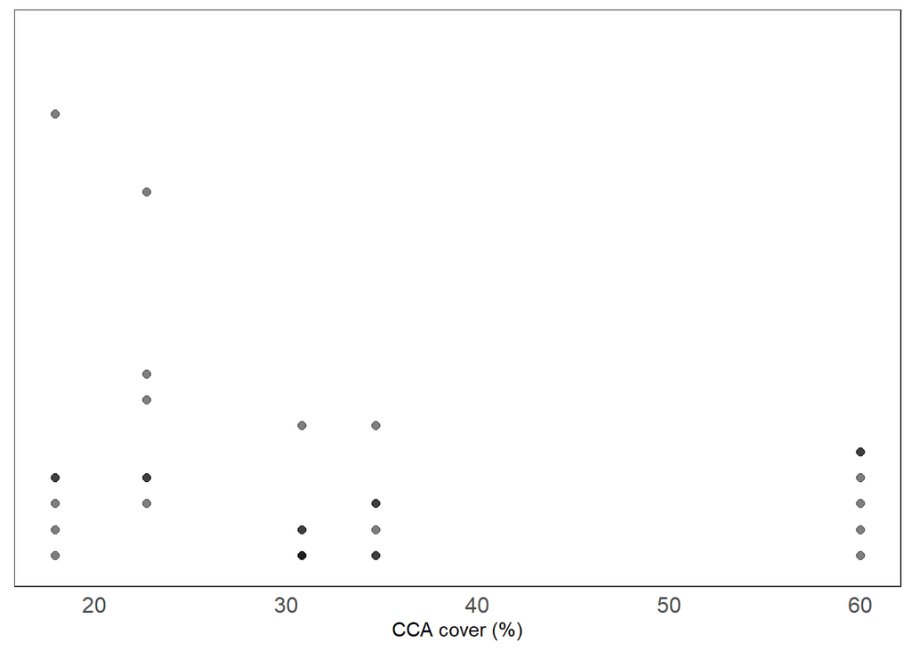

```r
EC_Rec6 <- ggplot() +
   geom_point(data = Rec6,                      # adding the raw data (scaled values)
              aes(x = Encrusting_macroalgae, y = Total_recruitment), size= 2, alpha=.5) +
   labs(x = "CCA cover (%)", y = "log(Total recruitment)") +
   Theme1 +
  scale_y_continuous(limits = c(-0.2, 20), breaks = seq(0,20, by = 4))+
  theme(axis.title.y=element_blank(),
        axis.text.y=element_blank(), axis.title.x=element_text(size = 11))

EC_Rec6
```

6. Survival

```r
glm_S <- glmmTMB(Total_recruitment ~ Survival_Percentage + (1|Site_Code), data=Rec6, family = nbinom2(link = "log"))
summary(glm_S)
```

```
##  Family: nbinom2  ( log )
## Formula:          Total_recruitment ~ Survival_Percentage + (1 | Site_Code)
## Data: Rec6
##
##      AIC      BIC   logLik deviance df.resid
##    135.5    141.1    -63.8    127.5       26
##
## Random effects:
##
## Conditional model:
##  Groups    Name        Variance  Std.Dev.
##  Site_Code (Intercept) 4.676e-10 2.162e-05
## Number of obs: 30, groups:  Site_Code, 5
##
## Dispersion parameter for nbinom2 family (): 1.63
##
## Conditional model:
##                     Estimate Std. Error z value Pr(>|z|)
## (Intercept)         -0.36939    0.49824  -0.741  0.45846
## Survival_Percentage  0.05248    0.01675   3.134  0.00173 **
## ---
## Signif. codes:  0 '***' 0.001 '**' 0.01 '*' 0.05 '.' 0.1 ' ' 1
```

```r
r.squaredGLMM(glm_S)
```

```
##                 R2m       R2c
## delta     0.2698461 0.2698461
## lognormal 0.3439223 0.3439223
## trigamma  0.1876801 0.1876801
```

```r
AICc(glm_S)
```

```
## [1] 137.1119
```

Check glm

```r
check_model(glm_S)
```

```
## `check_outliers()` does not yet support models of class `glmmTMB`.
```

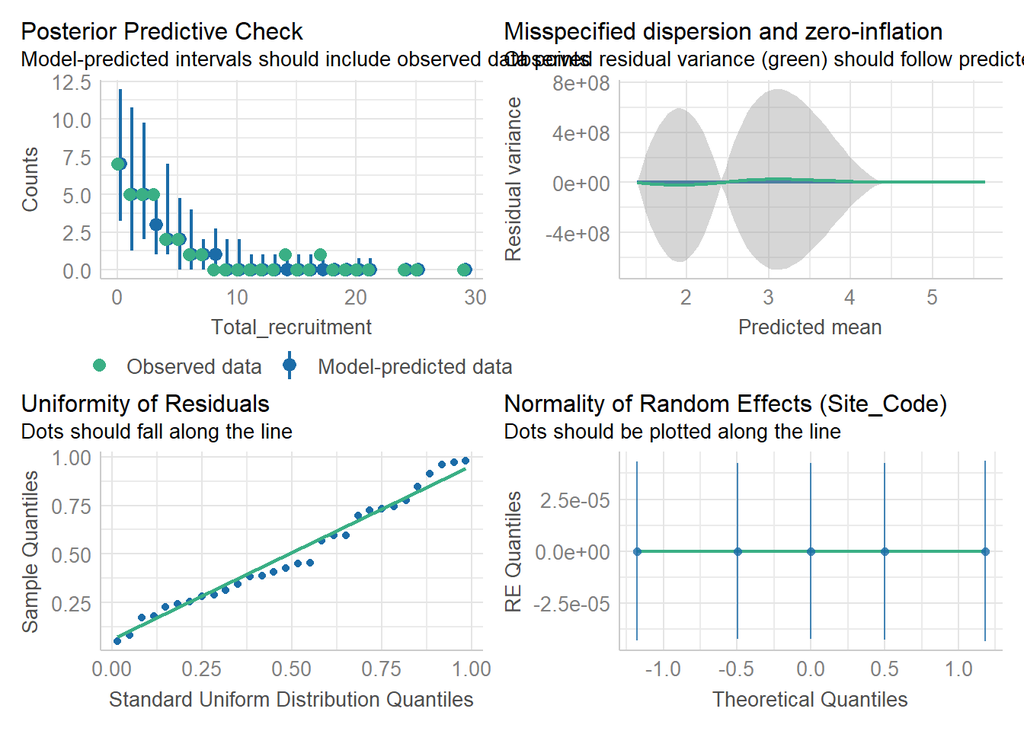

Plot relationships

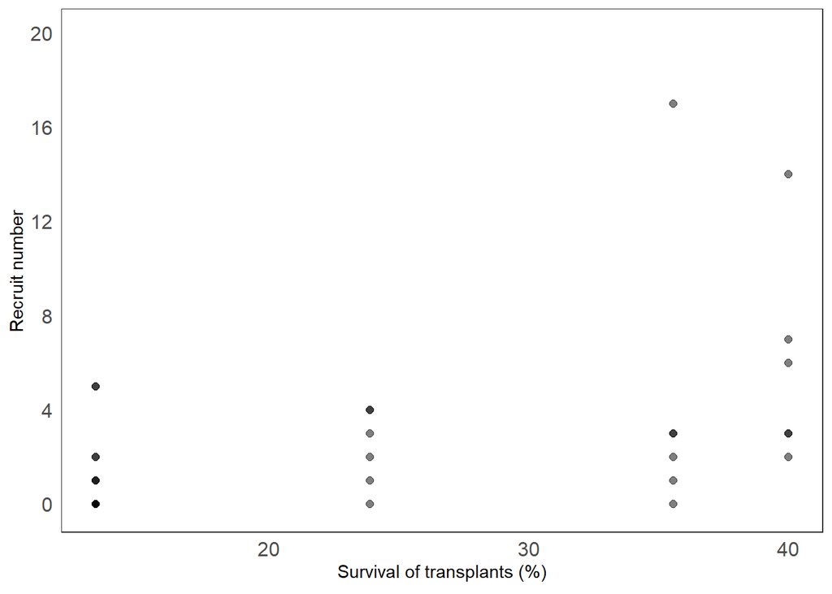

```r
Surv_Rec6 <- ggplot() +
   geom_point(data = Rec6,                      # adding the raw data (scaled values)
              aes(x = Survival_Percentage, y = Total_recruitment), size= 2, alpha=.5) +
   labs(x = expression ("Survival of transplants (%)"), y = expression("Recruit number")) +
   Theme1 +
  scale_y_continuous(limits = c(-0.2, 20), breaks = seq(0,20, by = 4))+
  theme(axis.title.x=element_text(size = 11), axis.title.y=element_text(size = 11))

Surv_Rec6
```

7. Grazing

```r
glm_S <- glmmTMB(Total_recruitment ~ Mean_Grazing + (1|Site_Code), data=Rec6, family = nbinom2(link = "log"))
summary(glm_S)
```

```
##  Family: nbinom2  ( log )
## Formula:          Total_recruitment ~ Mean_Grazing + (1 | Site_Code)
## Data: Rec6
##
##      AIC      BIC   logLik deviance df.resid
##    142.6    148.2    -67.3    134.6       26
##
## Random effects:
##
## Conditional model:
##  Groups    Name        Variance Std.Dev.
##  Site_Code (Intercept) 0.02048  0.1431
## Number of obs: 30, groups:  Site_Code, 5
##
## Dispersion parameter for nbinom2 family (): 1.12
##
## Conditional model:
##              Estimate Std. Error z value Pr(>|z|)
## (Intercept)    1.6619     0.7057   2.355   0.0185 *
## Mean_Grazing  -0.2129     0.2174  -0.979   0.3274
## ---
## Signif. codes:  0 '***' 0.001 '**' 0.01 '*' 0.05 '.' 0.1 ' ' 1
```

```r
r.squaredGLMM(glm_S)
```

```
##                  R2m        R2c
## delta     0.04849817 0.06418911
## lognormal 0.07177135 0.09499203
## trigamma  0.02748870 0.03638231
```

```r
AICc(glm_S)
```

```
## [1] 144.2147
```

```r
check_model(glm_S)
```

```
## `check_outliers()` does not yet support models of class `glmmTMB`.
```

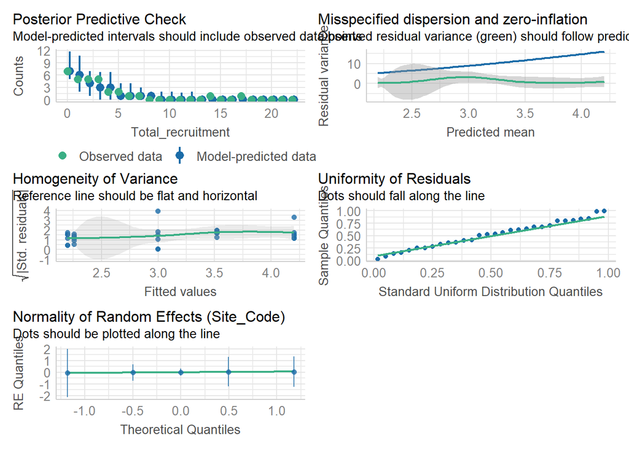

Plot relationships

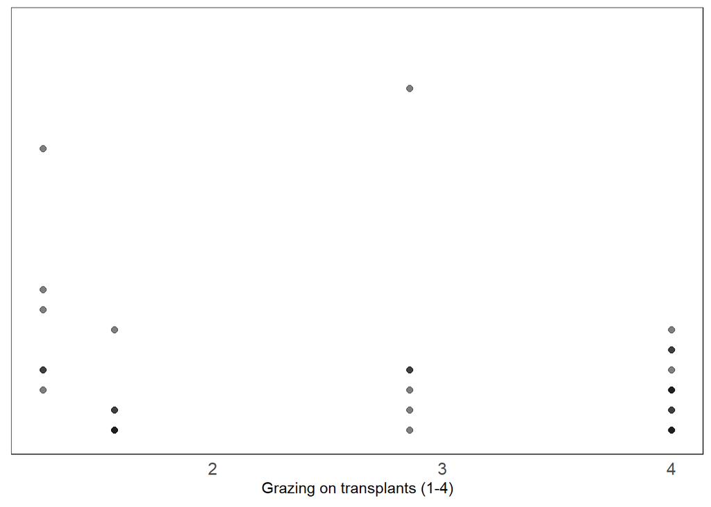

```r
Gr_Rec6 <- ggplot() +
   geom_point(data = Rec6,                      # adding the raw data (scaled values)
              aes(x = Mean_Grazing, y = Total_recruitment), size= 2, alpha=.5) +
   labs(x = expression ("Grazing on transplants (1-4)"), y = expression("Total Recruitment")) +
   Theme1 +
  scale_y_continuous(limits = c(-0.2, 20), breaks = seq(0,20, by = 4))+
  theme(axis.title.y=element_blank(),
        axis.text.y=element_blank(), axis.title.x=element_text(size = 11))


Gr_Rec6
```

8. Fouling

```r
glm_F <- glmmTMB(Total_recruitment ~ Percentage_fouling + (1|Site_Code), data=Rec6, family = nbinom2(link = "log"))
summary(glm_F)
```

```
##  Family: nbinom2  ( log )
## Formula:          Total_recruitment ~ Percentage_fouling + (1 | Site_Code)
## Data: Rec6
##
##      AIC      BIC   logLik deviance df.resid
##    143.4    149.0    -67.7    135.4       26
##
## Random effects:
##
## Conditional model:
##  Groups    Name        Variance Std.Dev.
##  Site_Code (Intercept) 0.1448   0.3805
## Number of obs: 30, groups:  Site_Code, 5
##
## Dispersion parameter for nbinom2 family ():  1.2
##
## Conditional model:
##                     Estimate Std. Error z value Pr(>|z|)
## (Intercept)         1.061160   0.522296   2.032   0.0422 *
## Percentage_fouling -0.000418   0.016165  -0.026   0.9794
## ---
## Signif. codes:  0 '***' 0.001 '**' 0.01 '*' 0.05 '.' 0.1 ' ' 1
```

```r
r.squaredGLMM(glm_F)
```

```
##                    R2m        R2c
## delta     3.684682e-05 0.11123133
## lognormal 5.251208e-05 0.15852082
## trigamma  2.191809e-05 0.06616524
```

```r
AICc(glm_F)
```

```
## [1] 145.0417
```

```r
check_model(glm_F)
```

```
## `check_outliers()` does not yet support models of class `glmmTMB`.
```

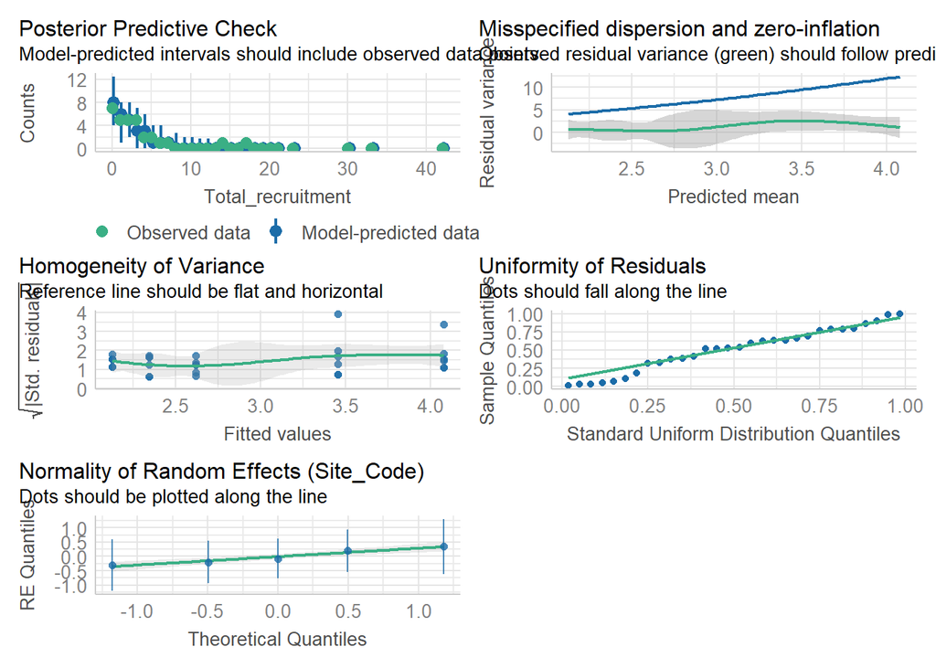

Plot relationships

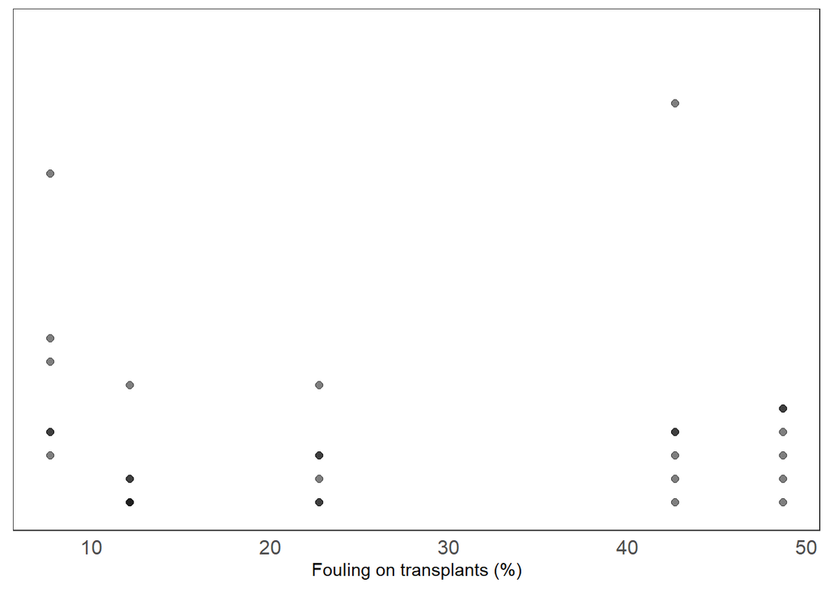

```r
Fo_Rec6 <- ggplot() +
   geom_point(data = Rec6,                      # adding the raw data (scaled values)
              aes(x = Percentage_fouling, y = Total_recruitment), size= 2, alpha=.5) +
   labs(x = expression ("Fouling on transplants (%)"), y = expression("Total Recruitment")) +
   Theme1 +
  scale_y_continuous(limits = c(-0.2, 20), breaks = seq(0,20, by = 4))+
  theme(axis.title.y=element_blank(),
        axis.text.y=element_blank(), axis.title.x=element_text(size = 11))


Fo_Rec6
```

9. Mean_SD

```r
glm_S <- glmmTMB(Total_recruitment ~ Mean_SD + (1|Site_Code), data=Rec6, family = nbinom2(link = "log"))
summary(glm_S)
```

```
##  Family: nbinom2  ( log )
## Formula:          Total_recruitment ~ Mean_SD + (1 | Site_Code)
## Data: Rec6
##
##      AIC      BIC   logLik deviance df.resid
##    143.0    148.6    -67.5    135.0       26
##
## Random effects:
##
## Conditional model:
##  Groups    Name        Variance Std.Dev.
##  Site_Code (Intercept) 0.1102   0.332
## Number of obs: 30, groups:  Site_Code, 5
##
## Dispersion parameter for nbinom2 family (): 1.19
##
## Conditional model:
##             Estimate Std. Error z value Pr(>|z|)
## (Intercept)   0.6624     0.6430   1.030    0.303
## Mean_SD      15.0708    22.6306   0.666    0.505
```

```r
r.squaredGLMM(glm_S)
```

```
##                  R2m        R2c
## delta     0.02455352 0.10901616
## lognormal 0.03507139 0.15571490
## trigamma  0.01455794 0.06463639
```

```r
AICc(glm_S)
```

```
## [1] 144.6224
```

```r
check_model(glm_S)
```

```
## `check_outliers()` does not yet support models of class `glmmTMB`.
```

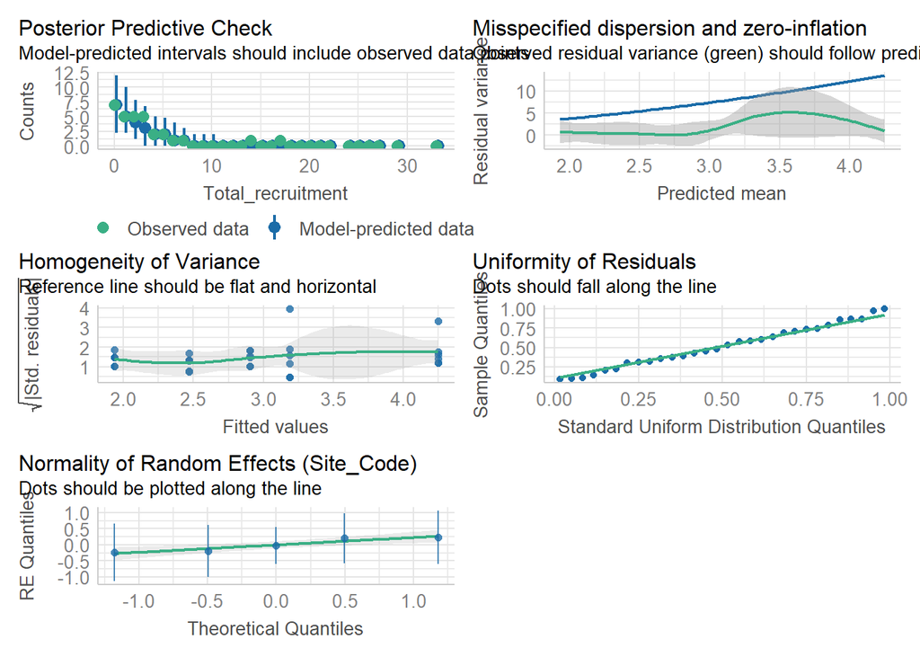

Plot relationships

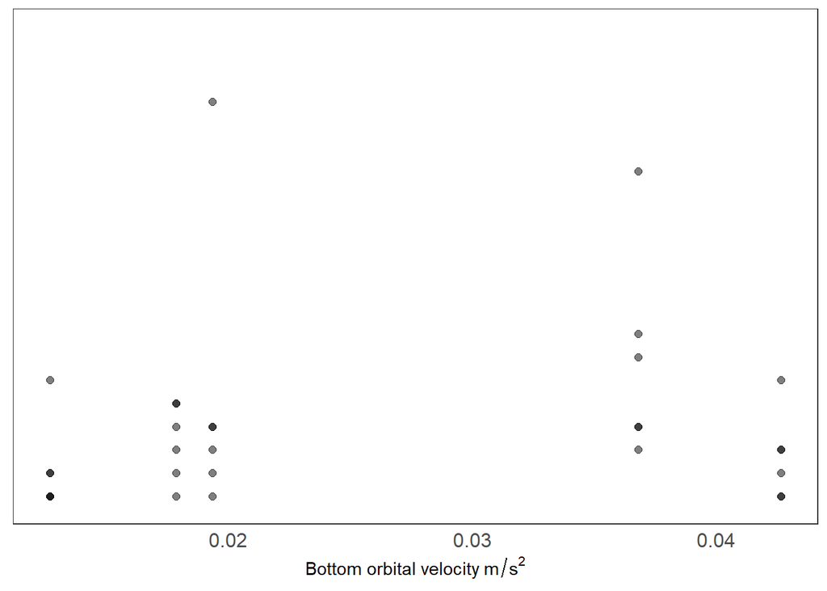

```r
SD_Rec6 <- ggplot() +
   geom_point(data = Rec6,                      # adding the raw data (scaled values)
              aes(x = Mean_SD, y = Total_recruitment), size= 2, alpha=.5) +
   labs(x = expression ("Bottom orbital velocity"~m/s^2), y = "log(Total recruitment + 1)") +
   Theme1 +
  scale_y_continuous(limits = c(-0.2, 20), breaks = seq(0,20, by = 4))+
    theme(axis.title.y=element_blank(),
        axis.text.y=element_blank(), axis.title.x=element_text(size = 11))

SD_Rec6
```

10. Mean light intensity

```r
glmm_Temp <- glmmTMB(Total_recruitment ~ Mean_Intensity + (1|Site_Code), data=Rec6, family = nbinom2(link = "log"))
summary(glmm_Temp )
```

```
##  Family: nbinom2  ( log )
## Formula:          Total_recruitment ~ Mean_Intensity + (1 | Site_Code)
## Data: Rec6
##
##      AIC      BIC   logLik deviance df.resid
##    143.4    149.0    -67.7    135.4       26
##
## Random effects:
##
## Conditional model:
##  Groups    Name        Variance Std.Dev.
##  Site_Code (Intercept) 0.1449   0.3806
## Number of obs: 30, groups:  Site_Code, 5
##
## Dispersion parameter for nbinom2 family ():  1.2
##
## Conditional model:
##                  Estimate Std. Error z value Pr(>|z|)
## (Intercept)     1.284e+00  1.856e+00   0.692    0.489
## Mean_Intensity -2.348e-05  1.839e-04  -0.128    0.898
```

```r
r.squaredGLMM(glmm_Temp)
```

```
##                    R2m        R2c
## delta     0.0008408547 0.11206912
## lognormal 0.0011976684 0.15962525
## trigamma  0.0005005193 0.06670921
```

```r
AICc(glmm_Temp)
```

```
## [1] 145.026
```

```r
check_model(glmm_Temp)
```

```
## `check_outliers()` does not yet support models of class `glmmTMB`.
```

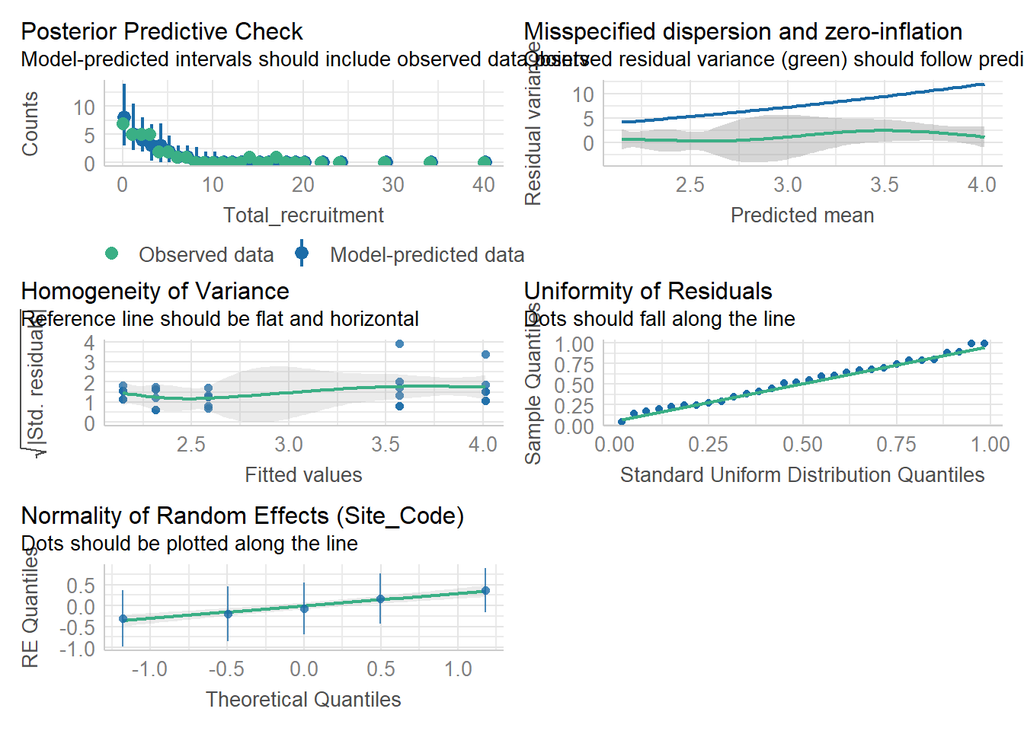

Plot relationships

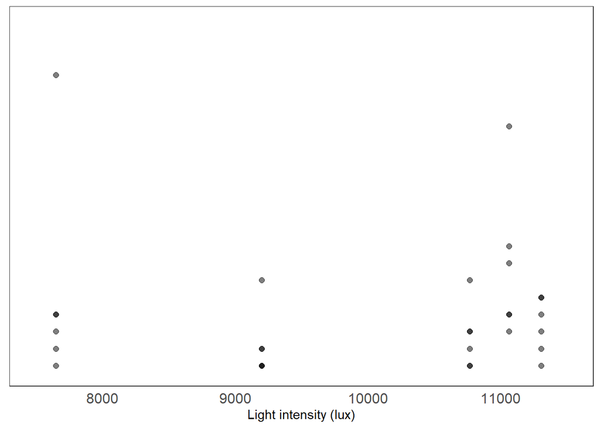

```r
T_Rec6 <- ggplot() +
   geom_point(data = Rec6,                      # adding the raw data (scaled values)
              aes(x = Mean_Intensity, y = Total_recruitment), size= 2, alpha=.5) +
   labs(x = "Light intensity (lux)", y = "log(Total recruitment)") +
   Theme1 +
  scale_y_continuous(limits = c(-0.2, 20), breaks = seq(0,20, by = 4))+
  scale_x_continuous(limits = c(7500, 11500), breaks = seq(8000,11000, by = 1000))+
  theme(axis.title.y=element_blank(),
        axis.text.y=element_blank(), axis.title.x=element_text(size = 11))

T_Rec6
```

11. Create Supplementary Figure 1

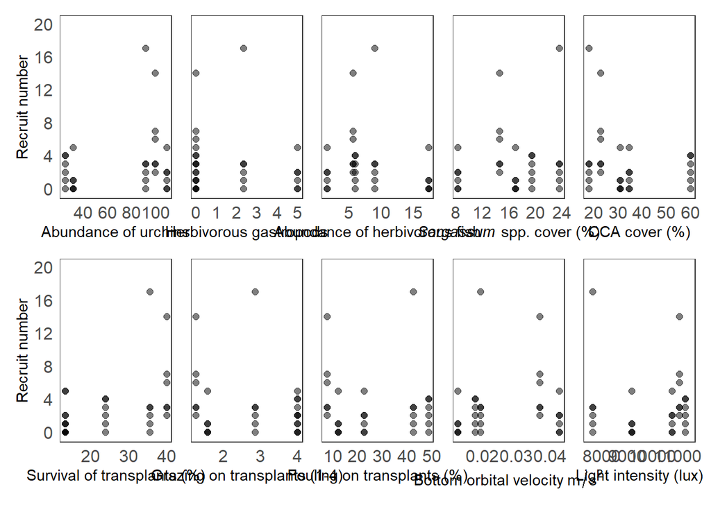

```r
U_Rec6 + SN_Rec6 + HF_Rec6 + SAR_Rec6 + EC_Rec6 + Surv_Rec6 + Gr_Rec6 + Fo_Rec6 + SD_Rec6 +T_Rec6 + plot_layout(ncol=5)
```

```r
ggsave("R6_predictors.jpeg", width = 30, height = 15, units = "cm")
```

### **5b)** Recruitment 9 months

1. Abundance of urchins

```r
my_lmerOX <- glmmTMB(Total_recruitment ~ Urchin + (1|Site_Code), data=Rec9, family = nbinom2(link = "log"))
summary(my_lmerOX)
```

```
##  Family: nbinom2  ( log )
## Formula:          Total_recruitment ~ Urchin + (1 | Site_Code)
## Data: Rec9
##
##      AIC      BIC   logLik deviance df.resid
##    121.6    127.2    -56.8    113.6       26
##
## Random effects:
##
## Conditional model:
##  Groups    Name        Variance Std.Dev.
##  Site_Code (Intercept) 2.05     1.432
## Number of obs: 30, groups:  Site_Code, 5
##
## Dispersion parameter for nbinom2 family (): 1.36
##
## Conditional model:
##             Estimate Std. Error z value Pr(>|z|)
## (Intercept) -1.83541    1.76026  -1.043    0.297
## Urchin       0.02772    0.02083   1.331    0.183
```

```r
r.squaredGLMM(my_lmerOX)
```

```
##                 R2m       R2c
## delta     0.2524623 0.7648031
## lognormal 0.2713000 0.8218698
## trigamma  0.2212199 0.6701583
```

```r
AICc(my_lmerOX)
```

```
## [1] 123.2017
```

```r
check_model(my_lmerOX)
```

```
## `check_outliers()` does not yet support models of class `glmmTMB`.
```

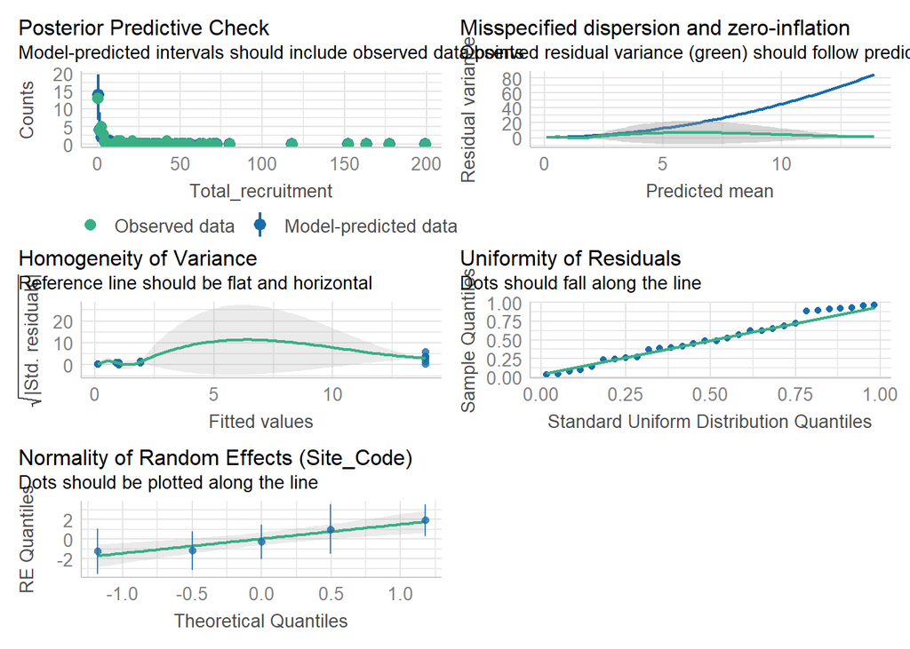

Plot relationship

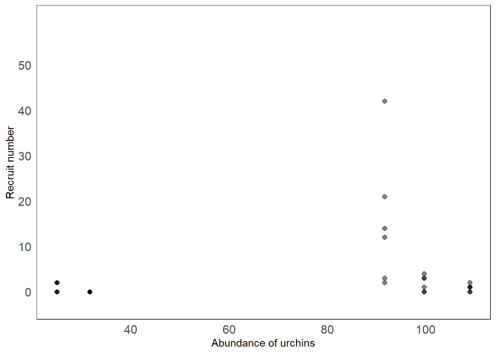

```r
U_Rec9 <- ggplot() +
   geom_point(data = Rec9,                      # adding the raw data (scaled values)
              aes(x = Urchin, y = Total_recruitment), size= 2, alpha=.5) +
   labs(x = "Abundance of urchins", y = expression("Recruit number")) +
   Theme1 +
  scale_y_continuous(limits = c(-3, 60), breaks = seq(0,50, by = 10)) +
  theme(axis.title.x=element_text(size = 11), axis.title.y=element_text(size = 11))

U_Rec9
```

2. Abundance of gastropods

```r
my_lmerOX <- glmmTMB(Total_recruitment ~ Herbivorous_invert + (1|Site_Code), data=Rec9, family = nbinom2(link = "log"))
summary(my_lmerOX)
```

```
##  Family: nbinom2  ( log )
## Formula:          Total_recruitment ~ Herbivorous_invert + (1 | Site_Code)
## Data: Rec9
##
##      AIC      BIC   logLik deviance df.resid
##    123.0    128.6    -57.5    115.0       26
##
## Random effects:
##
## Conditional model:
##  Groups    Name        Variance Std.Dev.
##  Site_Code (Intercept) 2.699    1.643
## Number of obs: 30, groups:  Site_Code, 5
##
## Dispersion parameter for nbinom2 family (): 1.36
##
## Conditional model:
##                    Estimate Std. Error z value Pr(>|z|)
## (Intercept)         -0.1886     1.0466  -0.180    0.857
## Herbivorous_invert   0.2385     0.4024   0.593    0.553
```

```r
r.squaredGLMM(my_lmerOX)
```

```
##                  R2m       R2c
## delta     0.05984432 0.7570041
## lognormal 0.06446858 0.8154990
## trigamma  0.05222572 0.6606322
```

```r
AICc(my_lmerOX)
```

```
## [1] 124.5658
```

```r
check_model(my_lmerOX)
```

```
## `check_outliers()` does not yet support models of class `glmmTMB`.
```

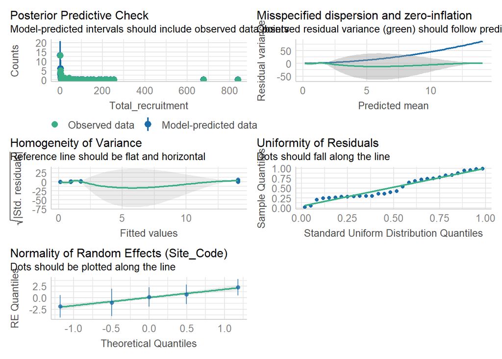

Plot relationship

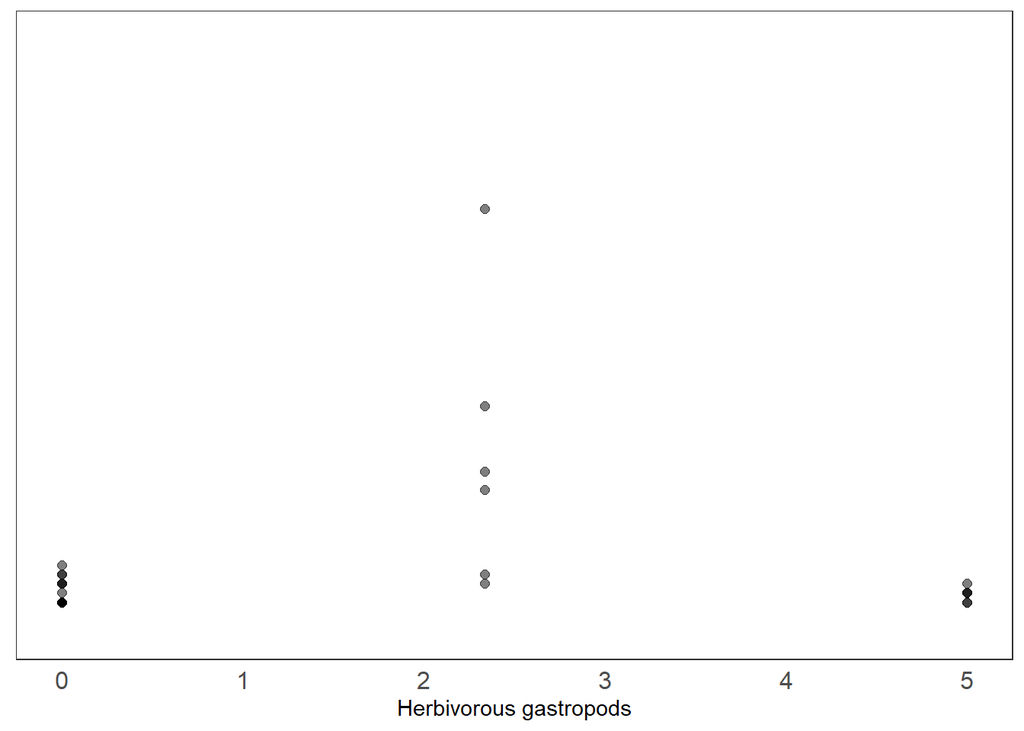

```r
SN_Rec9 <- ggplot() +
   geom_point(data = Rec9,                      # adding the raw data (scaled values)
              aes(x = Herbivorous_invert, y = Total_recruitment), size= 2, alpha=.5) +
   labs(x = "Herbivorous gastropods", y = "log(Total recruitment)") +
   Theme1 +
  scale_y_continuous(limits = c(-3, 60), breaks = seq(0,50, by = 10))+
  theme(axis.title.y=element_blank(),
        axis.text.y=element_blank(), axis.title.x=element_text(size = 11))

SN_Rec9
```

3. Abundance of herbivorous fish

```r
my_lmerOX <- glmmTMB(Total_recruitment ~ Mean_Abundance + (1|Site_Code), data=Rec9, family = nbinom2(link = "log"))
summary(my_lmerOX)
```

```
##  Family: nbinom2  ( log )
## Formula:          Total_recruitment ~ Mean_Abundance + (1 | Site_Code)
## Data: Rec9
##
##      AIC      BIC   logLik deviance df.resid
##    122.0    127.6    -57.0    114.0       26
##
## Random effects:
##
## Conditional model:
##  Groups    Name        Variance Std.Dev.
##  Site_Code (Intercept) 2.804    1.674
## Number of obs: 30, groups:  Site_Code, 5
##
## Dispersion parameter for nbinom2 family (): 1.36
##
## Conditional model:
##                Estimate Std. Error z value Pr(>|z|)
## (Intercept)      1.6266     1.5728   1.034    0.301
## Mean_Abundance  -0.2027     0.2010  -1.008    0.313
```

```r
r.squaredGLMM(my_lmerOX)
```

```
##                 R2m       R2c
## delta     0.2380702 0.8087290
## lognormal 0.2523047 0.8570839
## trigamma  0.2135795 0.7255335
```

```r
AICc(my_lmerOX)
```

```
## [1] 123.6401
```

```r
check_model(my_lmerOX)
```

```
## `check_outliers()` does not yet support models of class `glmmTMB`.
```

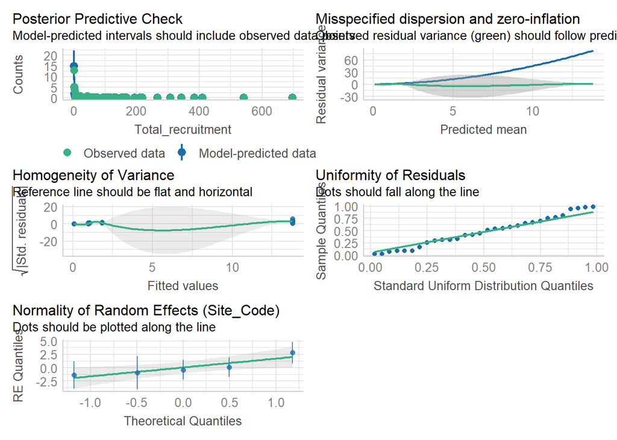

Plot relationship

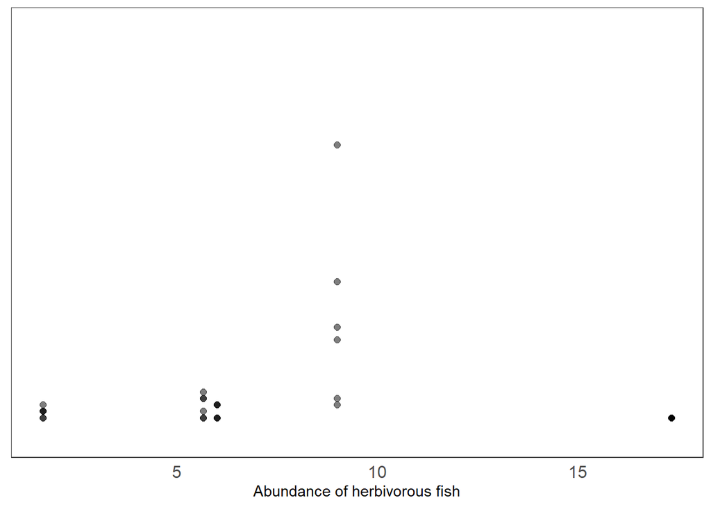

```r
HF_Rec9 <- ggplot() +
   geom_point(data = Rec9,                      # adding the raw data (scaled values)
              aes(x = Mean_Abundance, y = Total_recruitment), size= 2, alpha=.5) +
   labs(x = "Abundance of herbivorous fish", y = expression(sqrt("Total Recruitment"))) +
   Theme1 +
  scale_y_continuous(limits = c(-3, 60), breaks = seq(0,50, by = 10))+
  theme(axis.title.y=element_blank(),
        axis.text.y=element_blank(), axis.title.x=element_text(size = 11))

HF_Rec9
```

4. Sargassum cover

```r
my_lmerOX <- glmmTMB(Total_recruitment ~ Sargassum + (1|Site_Code), data=Rec9, family = nbinom2(link = "log"))
summary(my_lmerOX)
```

```
##  Family: nbinom2  ( log )
## Formula:          Total_recruitment ~ Sargassum + (1 | Site_Code)
## Data: Rec9
##
##      AIC      BIC   logLik deviance df.resid
##    122.1    127.7    -57.0    114.1       26
##
## Random effects:
##
## Conditional model:
##  Groups    Name        Variance Std.Dev.
##  Site_Code (Intercept) 1.716    1.31
## Number of obs: 30, groups:  Site_Code, 5
##
## Dispersion parameter for nbinom2 family (): 1.35
##
## Conditional model:
##             Estimate Std. Error z value Pr(>|z|)
## (Intercept)  -2.3393     2.1621  -1.082    0.279
## Sargassum     0.1562     0.1234   1.266    0.206
```

```r
r.squaredGLMM(my_lmerOX)
```

```
##                 R2m       R2c
## delta     0.1982845 0.7155466
## lognormal 0.2164961 0.7812668
## trigamma  0.1692803 0.6108796
```

```r
  AICc(my_lmerOX)
```

```
## [1] 123.6872
```

```r
check_model(my_lmerOX)
```

```
## `check_outliers()` does not yet support models of class `glmmTMB`.
```

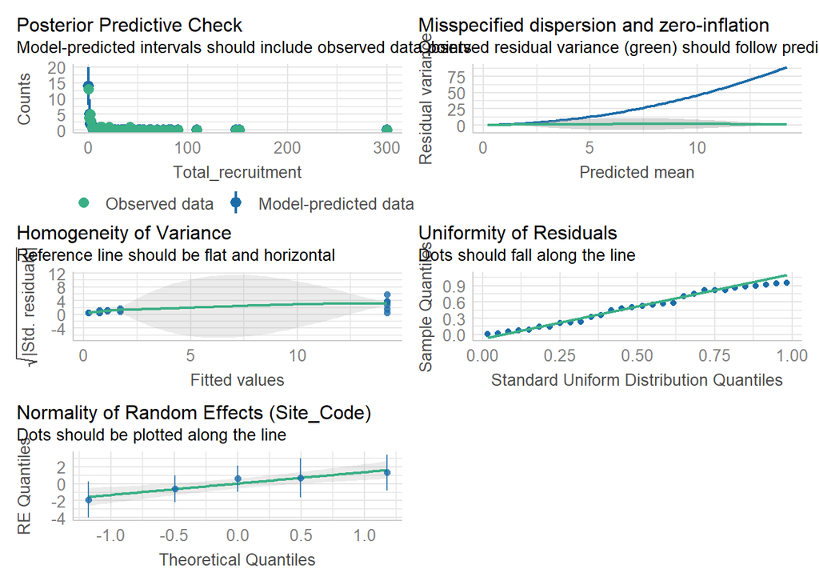

Plot relationship

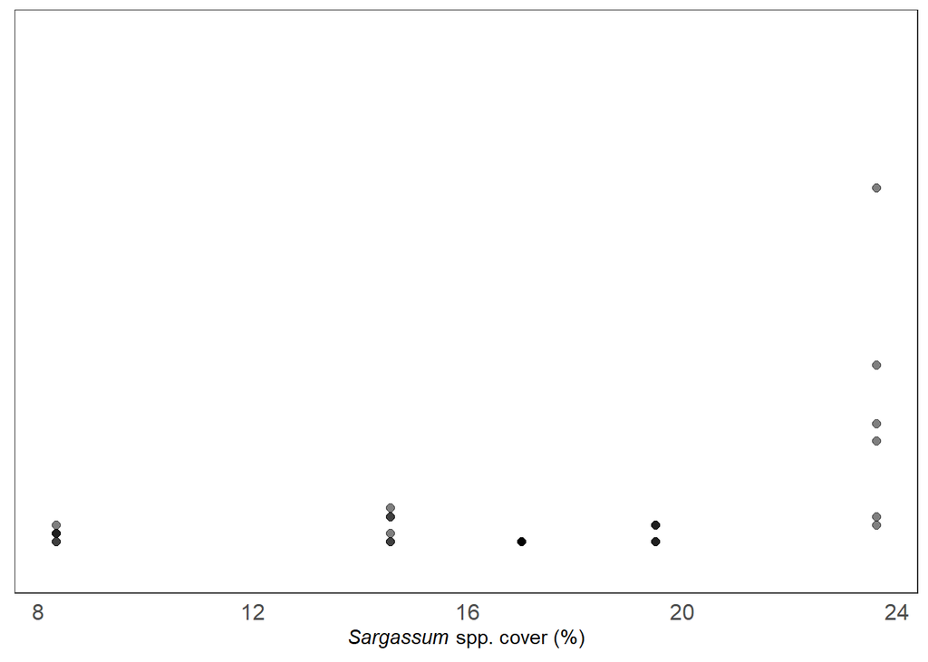

```r
SAR_Rec9 <- ggplot() +
   geom_point(data = Rec9,                      # adding the raw data (scaled values)
              aes(x = Sargassum, y = Total_recruitment), size= 2, alpha=.5) +
   labs(x = expression(paste(italic("Sargassum"), " spp. cover (%)")), y = "log(Total recruitment)") +
   Theme1 +
  scale_y_continuous(limits = c(-3, 60), breaks = seq(0,50, by = 10))+
  theme(axis.title.y=element_blank(),
        axis.text.y=element_blank(), axis.title.x=element_text(size = 11))

SAR_Rec9
```

5. CCA cover

```r
my_lmerOX <- glmmTMB(Total_recruitment ~ Encrusting_macroalgae + (1|Site_Code), data=Rec9, family = nbinom2(link = "log"))
summary(my_lmerOX)
```

```
##  Family: nbinom2  ( log )
## Formula:          Total_recruitment ~ Encrusting_macroalgae + (1 | Site_Code)
## Data: Rec9
##
##      AIC      BIC   logLik deviance df.resid
##    122.6    128.2    -57.3    114.6       26
##
## Random effects:
##
## Conditional model:
##  Groups    Name        Variance Std.Dev.
##  Site_Code (Intercept) 2.075    1.44
## Number of obs: 30, groups:  Site_Code, 5
##
## Dispersion parameter for nbinom2 family (): 1.35
##
## Conditional model:
##                       Estimate Std. Error z value Pr(>|z|)
## (Intercept)            1.69861    1.72056   0.987    0.324
## Encrusting_macroalgae -0.04423    0.04691  -0.943    0.346
```

```r
r.squaredGLMM(my_lmerOX)
```

```
##                 R2m       R2c
## delta     0.1254477 0.7268507
## lognormal 0.1364614 0.7906646
## trigamma  0.1077474 0.6242942
```

```r
AICc(my_lmerOX)
```

```
## [1] 124.1677
```

```r
check_model(my_lmerOX)
```

```
## `check_outliers()` does not yet support models of class `glmmTMB`.
```

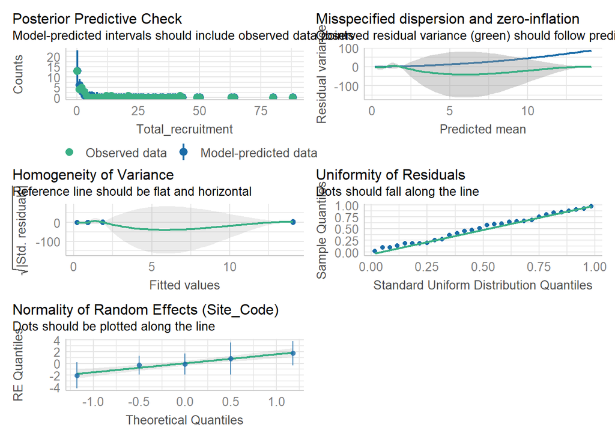

Plot relationship

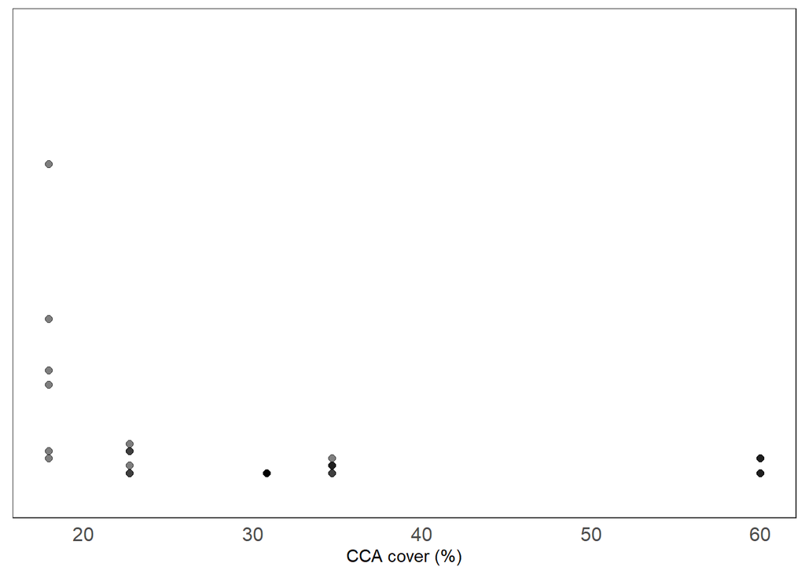

```r
EC_Rec9 <- ggplot() +
   geom_point(data = Rec9,                      # adding the raw data (scaled values)
              aes(x = Encrusting_macroalgae, y = Total_recruitment), size= 2, alpha=.5) +
   labs(x = "CCA cover (%)", y = "log(Total recruitment)") +
   Theme1 +
  scale_y_continuous(limits = c(-3, 60), breaks = seq(0,50, by = 10))+
  theme(axis.title.y=element_blank(),
        axis.text.y=element_blank(), axis.title.x=element_text(size = 11))

EC_Rec9
```

6. Survival

```r
glmm_Surv <- glmmTMB(Total_recruitment ~ Survival_Percentage + (1|Site_Code), data=Rec9, family = nbinom2(link = "log"))
summary(glmm_Surv)
```

```
##  Family: nbinom2  ( log )
## Formula:          Total_recruitment ~ Survival_Percentage + (1 | Site_Code)
## Data: Rec9
##
##      AIC      BIC   logLik deviance df.resid
##    119.5    125.1    -55.7    111.5       26
##
## Random effects:
##
## Conditional model:
##  Groups    Name        Variance Std.Dev.
##  Site_Code (Intercept) 1.109    1.053
## Number of obs: 30, groups:  Site_Code, 5
##
## Dispersion parameter for nbinom2 family (): 1.35
##
## Conditional model:
##                     Estimate Std. Error z value Pr(>|z|)
## (Intercept)         -2.72181    1.52363  -1.786   0.0740 .
## Survival_Percentage  0.11518    0.05161   2.232   0.0256 *
## ---
## Signif. codes:  0 '***' 0.001 '**' 0.01 '*' 0.05 '.' 0.1 ' ' 1
```

```r
r.squaredGLMM(glmm_Surv)
```

```
##                 R2m       R2c
## delta     0.4491990 0.7468462
## lognormal 0.4855369 0.8072623
## trigamma  0.3897949 0.6480799
```

```r
AICc(glmm_Surv)
```

```
## [1] 121.0596
```

```r
check_model(glmm_Surv)
```

```
## `check_outliers()` does not yet support models of class `glmmTMB`.
```

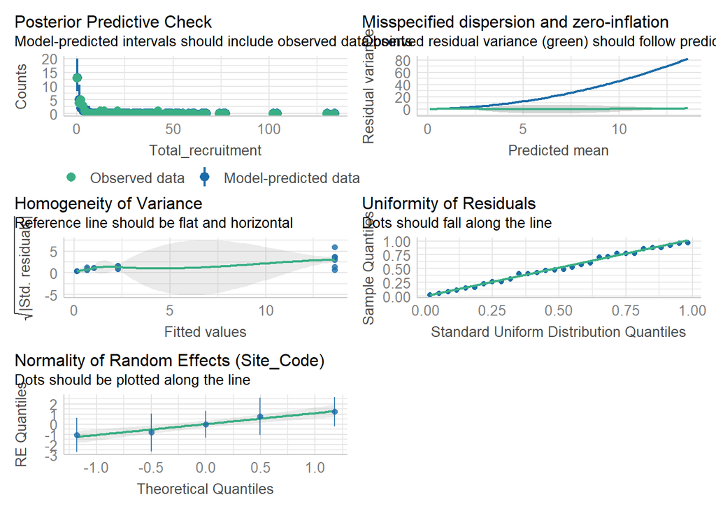

Calculate predicted values according to the model

```r
all_sites <- unique(Rec9$Site_Code)
new_data <-expand.grid(Survival_Percentage = seq(min(Rec9$Survival_Percentage), max(Rec9$Survival_Percentage), length.out = 100),
  Site_Code = all_sites)
predictions <- predict(glmm_Surv, newdata = new_data, type = "link", se.fit = TRUE, re.form = ~0)

# Combine predicted values with new_data
ilink <- family(glmm_Surv)$linkinv
pred <- cbind(new_data, predictions)
pred <- transform(pred, conf.low = ilink(fit - (2 * se.fit)),
                        conf.high = ilink(fit + (2 * se.fit)),
                        predicted = ilink(fit))
```

Plot relationship

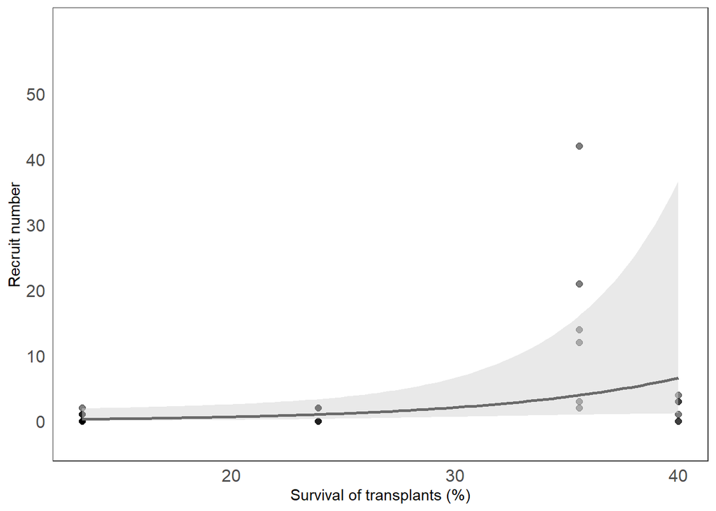

```r
Surv_Rec9 <- ggplot() +
   geom_point(data = Rec9,                      # adding the raw data (scaled values)
              aes(x = Survival_Percentage, y = Total_recruitment), size= 2, alpha=.5) +
   labs(x = "Survival of transplants (%)", y = expression("Recruit number")) +
   Theme1 +
  scale_y_continuous(limits = c(-3, 60), breaks = seq(0,50, by = 10)) +
  theme(axis.title.x=element_text(size = 11), axis.title.y=element_text(size = 11)) +
  geom_line(data = pred,
            aes(x = Survival_Percentage, y = predicted),
            color = "black", size = 1)   +
  geom_ribbon(data = pred,
              aes(x = Survival_Percentage, ymin = conf.low, ymax = conf.high),
              fill = "lightgrey", alpha = 0.5)


Surv_Rec9
```

```r
ggsave("R9_surv.jpeg", width = 90, height = 70, units = "mm")
```

7. Grazing

```r
my_lmerOX <- glmmTMB(Total_recruitment ~ Mean_Grazing + (1|Site_Code), data=Rec9, family = nbinom2(link = "log"))
summary(my_lmerOX)
```

```
##  Family: nbinom2  ( log )
## Formula:          Total_recruitment ~ Mean_Grazing + (1 | Site_Code)
## Data: Rec9
##
##      AIC      BIC   logLik deviance df.resid
##    123.1    128.7    -57.6    115.1       26
##
## Random effects:
##
## Conditional model:
##  Groups    Name        Variance Std.Dev.
##  Site_Code (Intercept) 2.864    1.692
## Number of obs: 30, groups:  Site_Code, 5
##
## Dispersion parameter for nbinom2 family (): 1.36
##
## Conditional model:
##              Estimate Std. Error z value Pr(>|z|)
## (Intercept)   -0.7369     2.2360  -0.330    0.742
## Mean_Grazing   0.3234     0.7239   0.447    0.655
```

```r
r.squaredGLMM(my_lmerOX)
```

```
##                  R2m       R2c
## delta     0.03697008 0.7619014
## lognormal 0.03976430 0.8194863
## trigamma  0.03234797 0.6666463
```

```r
AICc(my_lmerOX)
```

```
## [1] 124.712
```

```r
check_model(my_lmerOX)
```

```
## `check_outliers()` does not yet support models of class `glmmTMB`.
```

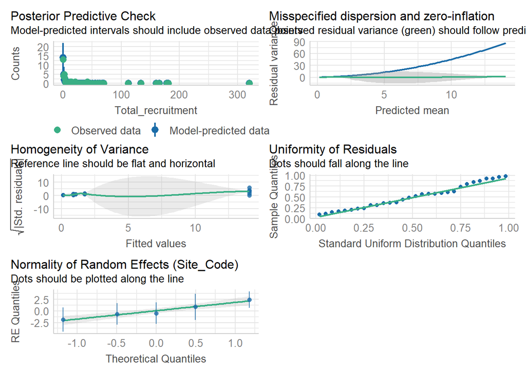

Plot relationship

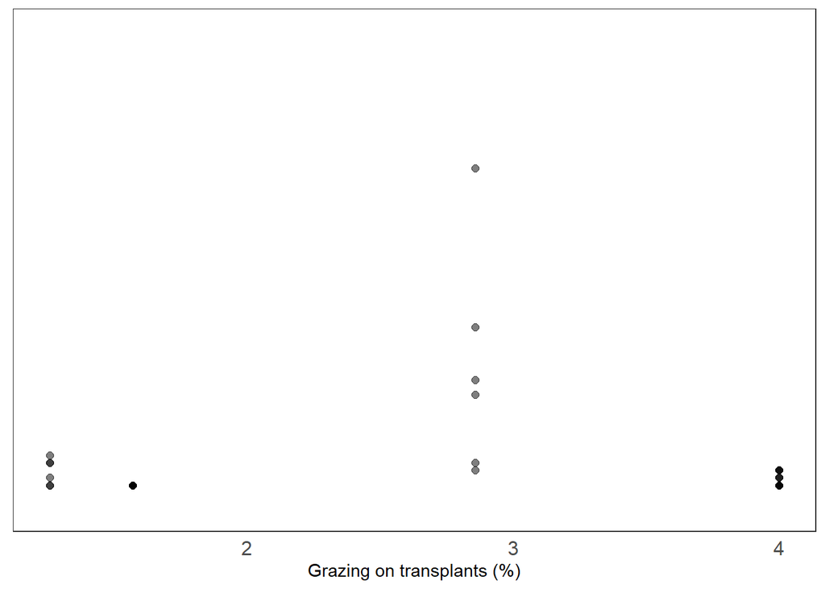

```r
Gr_Rec9 <- ggplot() +
   geom_point(data = Rec9,                      # adding the raw data (scaled values)
              aes(x = Mean_Grazing, y = Total_recruitment), size= 2, alpha=.5) +
   labs(x = "Grazing on transplants (%)", y = expression(sqrt("Total Recruitment"))) +
   Theme1 +
  scale_y_continuous(limits = c(-3, 60), breaks = seq(0,50, by = 10)) +
    theme(axis.title.y=element_blank(),
        axis.text.y=element_blank(), axis.title.x=element_text(size = 11))

Gr_Rec9
```

8. Fouling

```r
my_lmerOX <- glmmTMB(Total_recruitment ~ Percentage_fouling + (1|Site_Code), data=Rec9, family = nbinom2(link = "log"))
summary(my_lmerOX)
```

```
##  Family: nbinom2  ( log )
## Formula:          Total_recruitment ~ Percentage_fouling + (1 | Site_Code)
## Data: Rec9
##
##      AIC      BIC   logLik deviance df.resid
##    121.9    127.5    -57.0    113.9       26
##
## Random effects:
##
## Conditional model:
##  Groups    Name        Variance Std.Dev.
##  Site_Code (Intercept) 2.101    1.449
## Number of obs: 30, groups:  Site_Code, 5
##
## Dispersion parameter for nbinom2 family (): 1.36
##
## Conditional model:
##                    Estimate Std. Error z value Pr(>|z|)
## (Intercept)        -1.26495    1.46437  -0.864    0.388
## Percentage_fouling  0.05363    0.04411   1.216    0.224
```

```r
r.squaredGLMM(my_lmerOX)
```

```
##                 R2m       R2c
## delta     0.2061456 0.7543238
## lognormal 0.2222707 0.8133283
## trigamma  0.1796339 0.6573128
```

```r
AICc(my_lmerOX)
```

```
## [1] 123.5231
```

```r
check_model(my_lmerOX)
```

```
## `check_outliers()` does not yet support models of class `glmmTMB`.
```

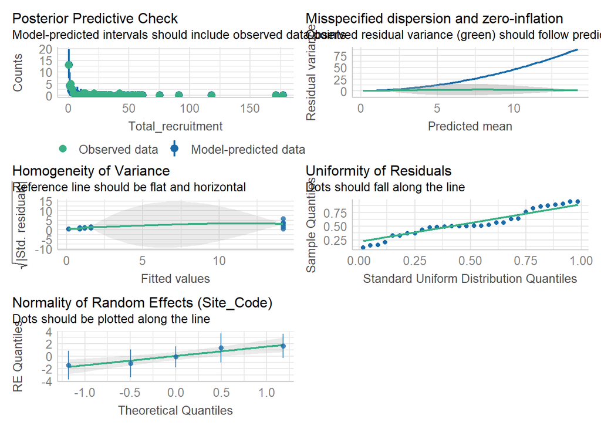

Plot relationship

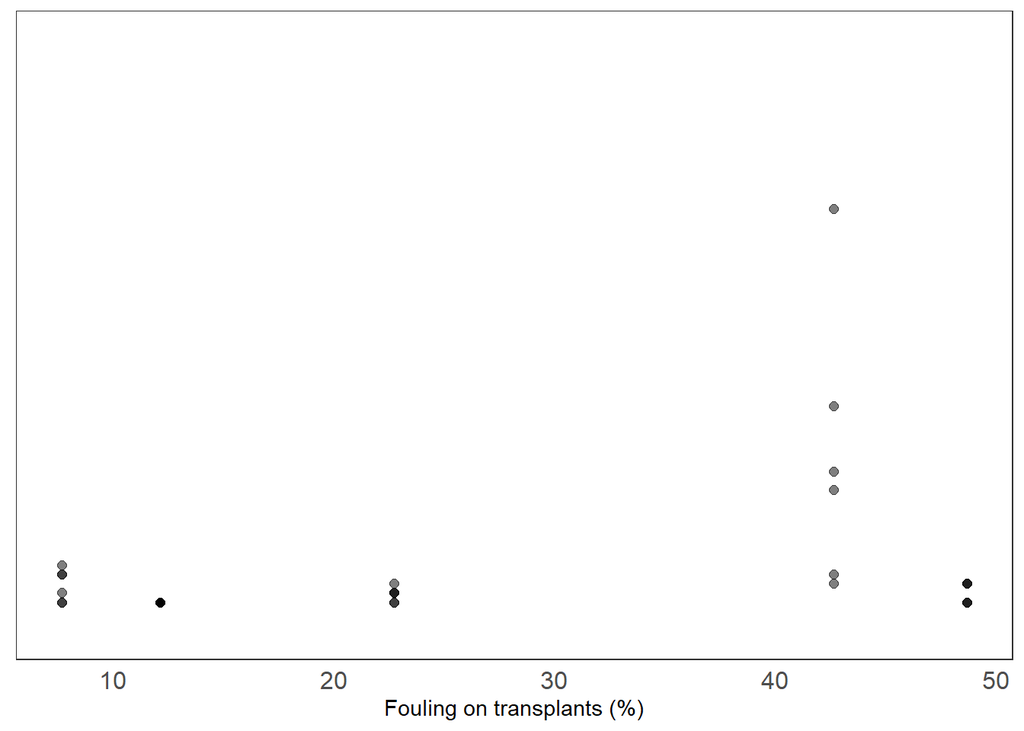

```r
Fo_Rec9 <- ggplot() +
   geom_point(data = Rec9,                      # adding the raw data (scaled values)
              aes(x = Percentage_fouling, y = Total_recruitment), size= 2, alpha=.5) +
   labs(x = "Fouling on transplants (%)", y = expression(sqrt("Total Recruitment"))) +
   Theme1 +
  scale_y_continuous(limits = c(-3, 60), breaks = seq(0,50, by = 10)) +
    theme(axis.title.y=element_blank(),
        axis.text.y=element_blank(), axis.title.x=element_text(size = 11))

Fo_Rec9
```

9. G-force - Daily SD

```r
my_lmerY <- glmmTMB(Total_recruitment ~ Mean_SD + (1|Site_Code), data=Rec9, family = nbinom2(link = "log"))
summary(my_lmerY)
```

```
##  Family: nbinom2  ( log )
## Formula:          Total_recruitment ~ Mean_SD + (1 | Site_Code)
## Data: Rec9
##
##      AIC      BIC   logLik deviance df.resid
##    123.2    128.8    -57.6    115.2       26
##
## Random effects:
##
## Conditional model:
##  Groups    Name        Variance Std.Dev.
##  Site_Code (Intercept) 2.928    1.711
## Number of obs: 30, groups:  Site_Code, 5
##
## Dispersion parameter for nbinom2 family (): 1.36
##
## Conditional model:
##             Estimate Std. Error z value Pr(>|z|)
## (Intercept)  -0.5813     2.2034  -0.264    0.792
## Mean_SD      27.9970    74.3429   0.377    0.706
```

```r
r.squaredGLMM(my_lmerY)
```

```
##                  R2m       R2c
## delta     0.02778902 0.7636815
## lognormal 0.02987218 0.8209299
## trigamma  0.02433815 0.6688468
```

```r
AICc(my_lmerY)
```

```
## [1] 124.7706
```

```r
check_model(my_lmerY)
```

```
## `check_outliers()` does not yet support models of class `glmmTMB`.
```

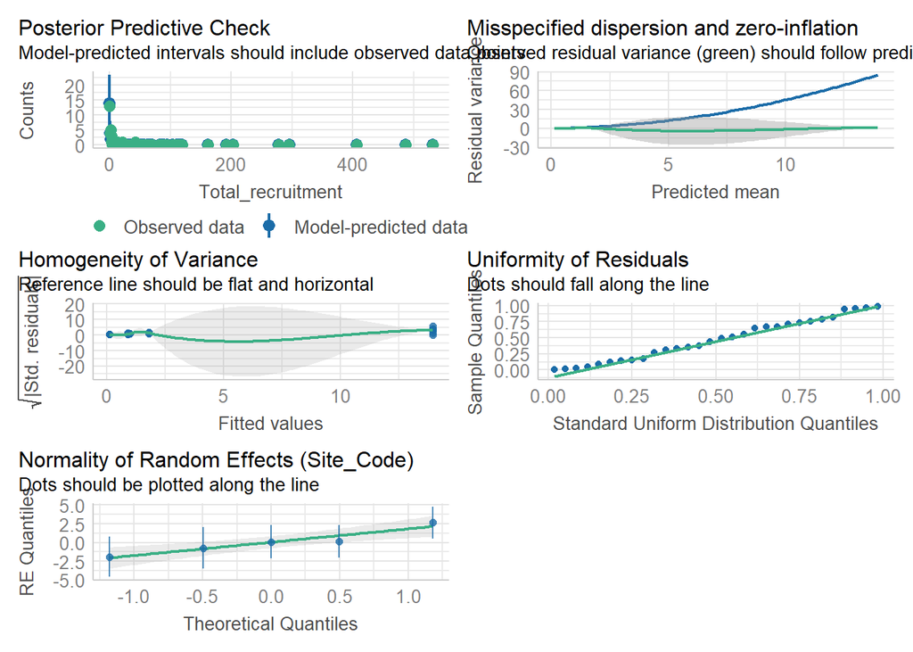

Plot relationship

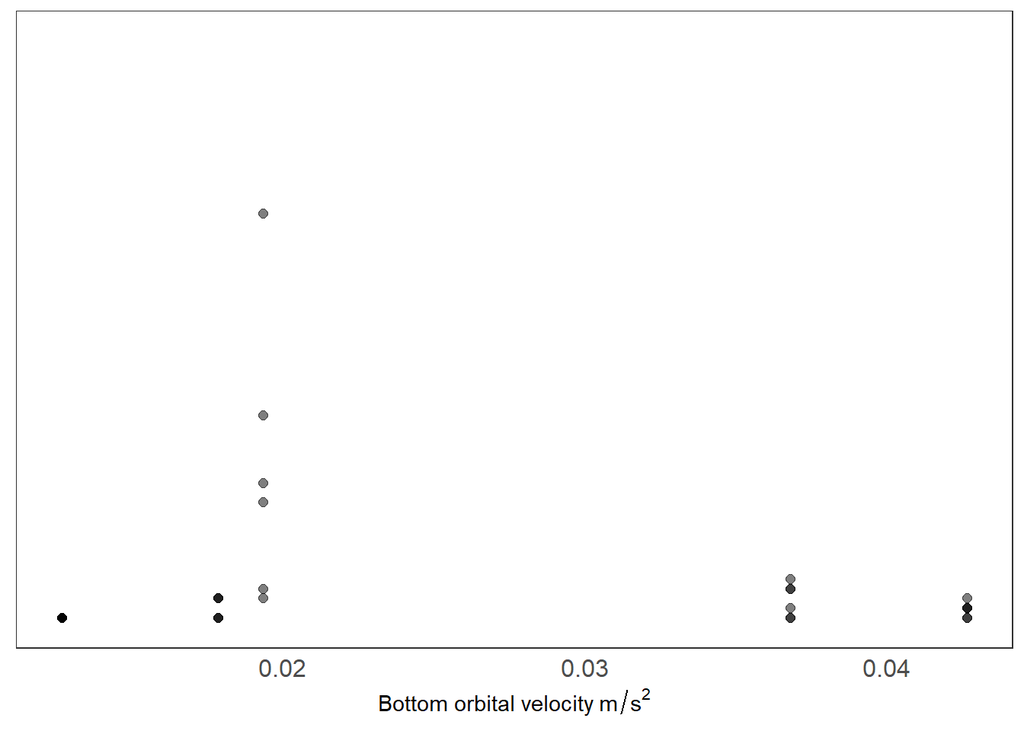

```r
SD_Rec9  <- ggplot()+
   geom_point(data = Rec9,                      # adding the raw data (scaled values)
              aes(x = Mean_SD, y = Total_recruitment), size= 2, alpha=.5) +
   labs(x = expression ("Bottom orbital velocity"~m/s^2), y = expression(sqrt("Total Recruitment"))) +
   Theme1 +
  scale_y_continuous(limits = c(-0.2, 60), breaks = seq(0,50, by = 10))+
  theme(axis.title.x=element_text(size = 11)) +
  theme(axis.title.y=element_blank(),
        axis.text.y=element_blank())
SD_Rec9
```

10. Mean light intensity

```r
glmm_T <- glmmTMB(Total_recruitment ~ Mean_Intensity + (1|Site_Code), data=Rec9, family = nbinom2(link = "log"))
summary(glmm_T)
```

```
##  Family: nbinom2  ( log )
## Formula:          Total_recruitment ~ Mean_Intensity + (1 | Site_Code)
## Data: Rec9
##
##      AIC      BIC   logLik deviance df.resid
##    122.5    128.1    -57.2    114.5       26
##
## Random effects:
##
## Conditional model:
##  Groups    Name        Variance Std.Dev.
##  Site_Code (Intercept) 1.784    1.336
## Number of obs: 30, groups:  Site_Code, 5
##
## Dispersion parameter for nbinom2 family (): 1.35
##
## Conditional model:
##                  Estimate Std. Error z value Pr(>|z|)
## (Intercept)     5.2351376  4.7308308   1.107    0.268
## Mean_Intensity -0.0004964  0.0004649  -1.068    0.286
```

```r
r.squaredGLMM(glmm_T)
```

```
##                 R2m       R2c
## delta     0.1521086 0.7065894
## lognormal 0.1665674 0.7737548
## trigamma  0.1292489 0.6003993
```

```r
AIC(glmm_T)
```

```
## [1] 122.4654
```

```r
check_model(glmm_T)
```

```
## `check_outliers()` does not yet support models of class `glmmTMB`.
```

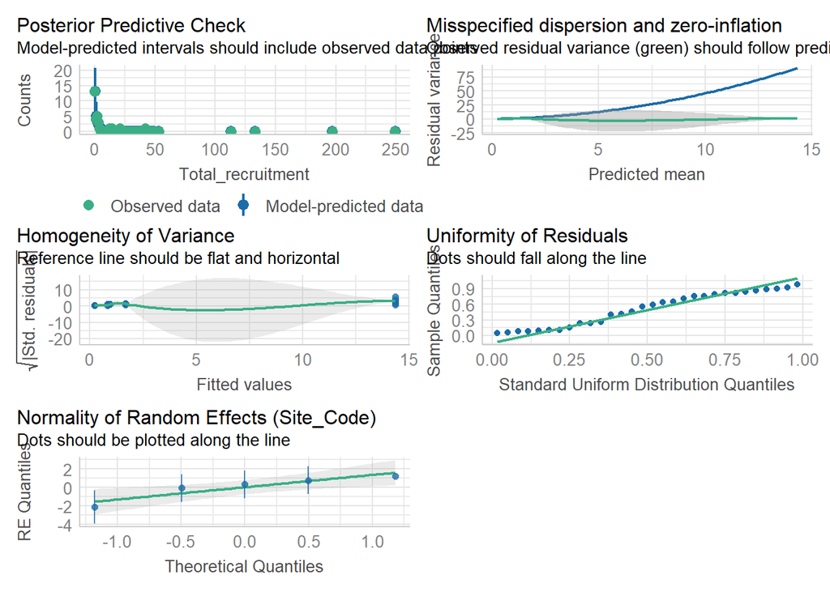

Plot relationship

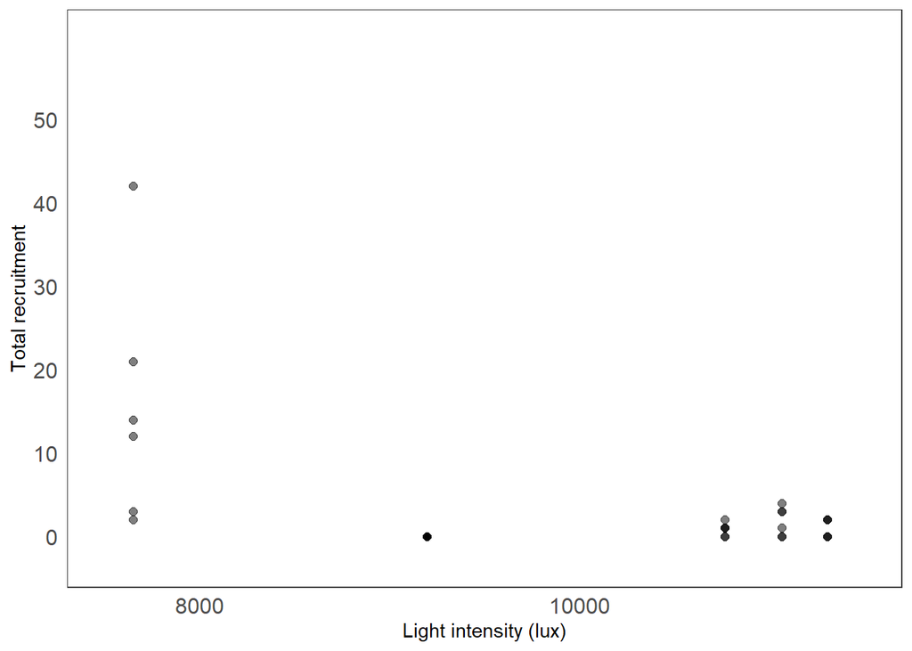

```r
T_Rec9 <- ggplot() +
   geom_point(data = Rec9,                      # adding the raw data (scaled values)
              aes(x = Mean_Intensity, y = Total_recruitment), size= 2, alpha=.5) +
   labs(x = "Light intensity (lux)", y = "Total recruitment") +
   Theme1 +
  scale_y_continuous(limits = c(-3, 60), breaks = seq(0,50, by = 10))+
  scale_x_continuous(limits = c(7500, 11500), breaks = seq(8000,11000, by = 2000))+
  theme(axis.title.x=element_text(size = 11), axis.title.y=element_text(size = 11))

T_Rec9
```

```r
ggsave("R9_T.jpeg", width = 110, height = 70, units = "mm")
```

```r
T_Rec9 <- T_Rec9+
  theme(axis.title.y=element_blank(),
        axis.text.y=element_blank())
```

11. Create Supplementary Figure 2

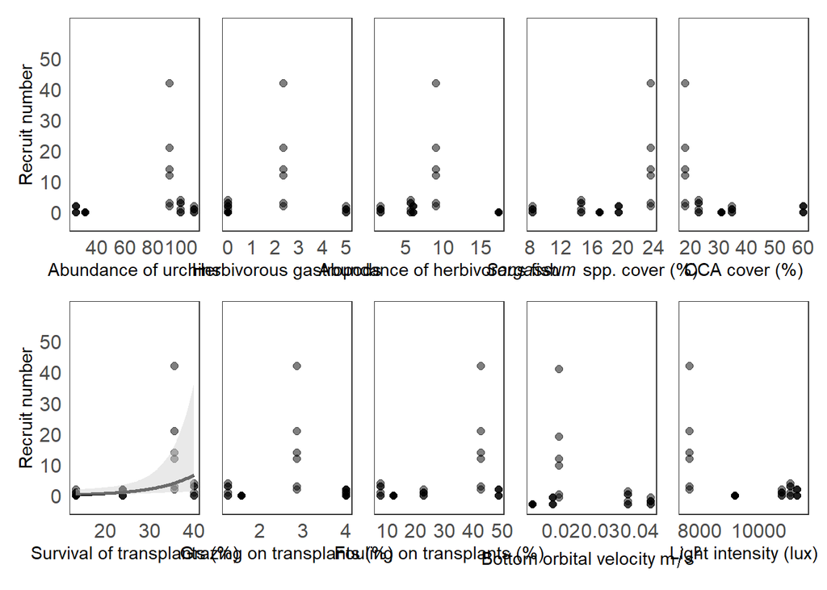

```r
U_Rec9 + SN_Rec9 + HF_Rec9 + SAR_Rec9 + EC_Rec9 + Surv_Rec9 + Gr_Rec9  + Fo_Rec9 + SD_Rec9 +  T_Rec9 + plot_layout(ncol=5)
```

```r
ggsave("R9_predictors.jpeg", width = 30, height = 15, units = "cm")
```

### **5c)** Recruit length 6 months

1. Abundance of urchins

```r
my_lmerOX <- glmmTMB(Recruit_size_inside_mat ~ Urchin + (1|Site_Code), data=Rec_l6, family = Gamma(link = "log"))
summary(my_lmerOX)
```

```
##  Family: Gamma  ( log )
## Formula:          Recruit_size_inside_mat ~ Urchin + (1 | Site_Code)
## Data: Rec_l6
##
##      AIC      BIC   logLik deviance df.resid
##     98.8    103.0    -45.4     90.8       17
##
## Random effects:
##
## Conditional model:
##  Groups    Name        Variance  Std.Dev.
##  Site_Code (Intercept) 1.092e-10 1.045e-05
## Number of obs: 21, groups:  Site_Code, 5
##
## Dispersion estimate for Gamma family (sigma^2): 0.207
##
## Conditional model:
##             Estimate Std. Error z value Pr(>|z|)
## (Intercept) 1.221326   0.228295   5.350 8.81e-08 ***
## Urchin      0.005284   0.002853   1.852    0.064 .
## ---
## Signif. codes:  0 '***' 0.001 '**' 0.01 '*' 0.05 '.' 0.1 ' ' 1
```

```r
r.squaredGLMM(my_lmerOX)
```

```
##                 R2m       R2c
## delta     0.1497298 0.1497298
## lognormal 0.1623329 0.1623329
## trigamma  0.1368323 0.1368323
```

```r
AICc(my_lmerOX)
```

```
## [1] 101.2807
```

```r
check_model(my_lmerOX)
```

```
## `check_outliers()` does not yet support models of class `glmmTMB`.
```

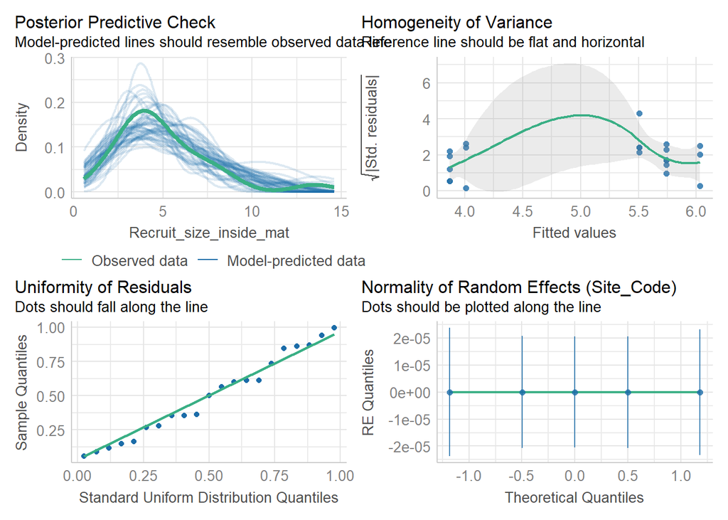

Plot relationship

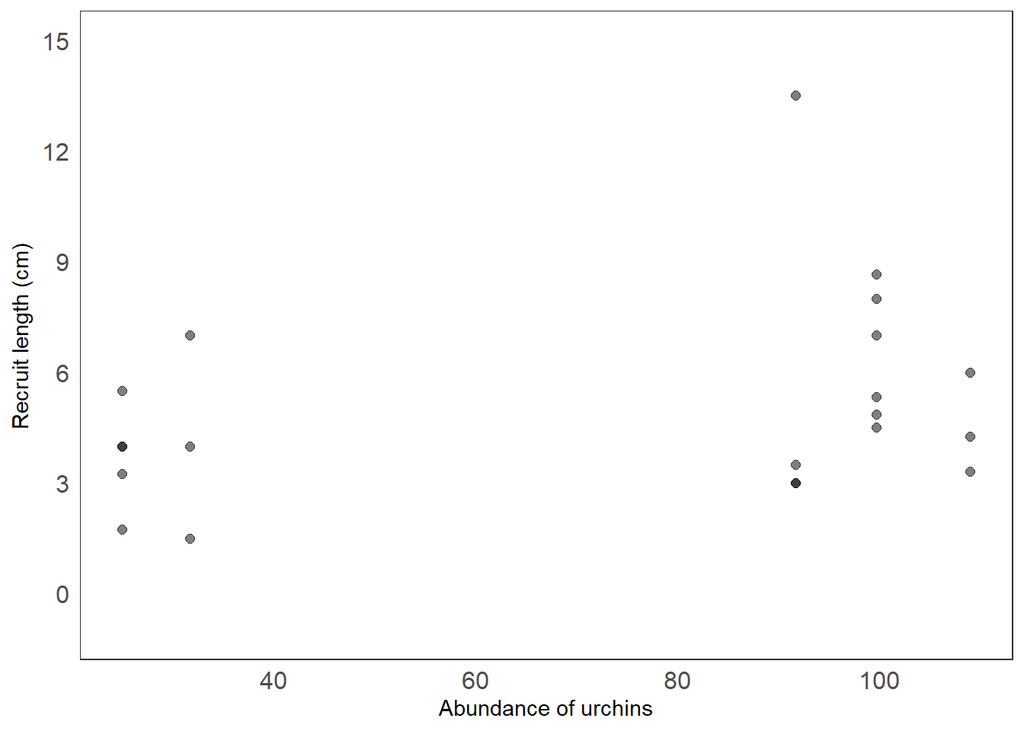

```r
U_Recl6 <- ggplot() +
   geom_point(data = Rec_l6,                      # adding the raw data (scaled values)
              aes(x = Urchin, y = Recruit_size_inside_mat), size= 2, alpha=.5) +
   labs(x = "Abundance of urchins", y = expression("Recruit length (cm)")) +
   Theme1 +
  scale_y_continuous(limits = c(-1, 15), breaks = seq(0,15, by = 3)) +
  theme(axis.title.x=element_text(size = 11), axis.title.y=element_text(size = 11))

U_Recl6
```

2. Abundance of gastropods

```r
my_lmerOX <- glmmTMB(Recruit_size_inside_mat ~ Herbivorous_invert + (1|Site_Code), data=Rec_l6, family = Gamma(link = "log"))
summary(my_lmerOX)
```

```
##  Family: Gamma  ( log )
## Formula:
## Recruit_size_inside_mat ~ Herbivorous_invert + (1 | Site_Code)
## Data: Rec_l6
##
##      AIC      BIC   logLik deviance df.resid
##    101.9    106.0    -46.9     93.9       17
##
## Random effects:
##
## Conditional model:
##  Groups    Name        Variance  Std.Dev.
##  Site_Code (Intercept) 5.146e-08 0.0002268
## Number of obs: 21, groups:  Site_Code, 5
##
## Dispersion estimate for Gamma family (sigma^2): 0.238
##
## Conditional model:
##                     Estimate Std. Error z value Pr(>|z|)
## (Intercept)         1.622638   0.127462  12.730   <2e-16 ***
## Herbivorous_invert -0.003989   0.060517  -0.066    0.947
## ---
## Signif. codes:  0 '***' 0.001 '**' 0.01 '*' 0.05 '.' 0.1 ' ' 1
```

```r
r.squaredGLMM(my_lmerOX)
```

```
##                    R2m          R2c
## delta     0.0002292912 0.0002295075
## lognormal 0.0002555892 0.0002558302
## trigamma  0.0002032274 0.0002034190
```

```r
AICc(my_lmerOX)
```

```
## [1] 104.3643
```

```r
check_model(my_lmerOX)
```

```
## `check_outliers()` does not yet support models of class `glmmTMB`.
```

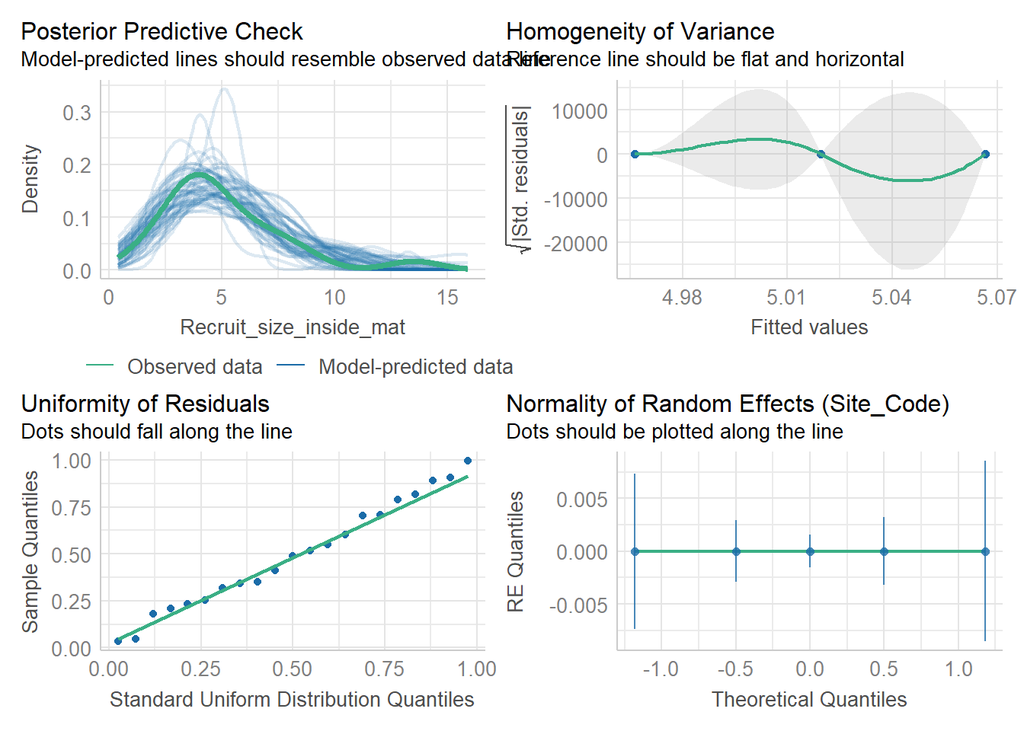

Plot relationship

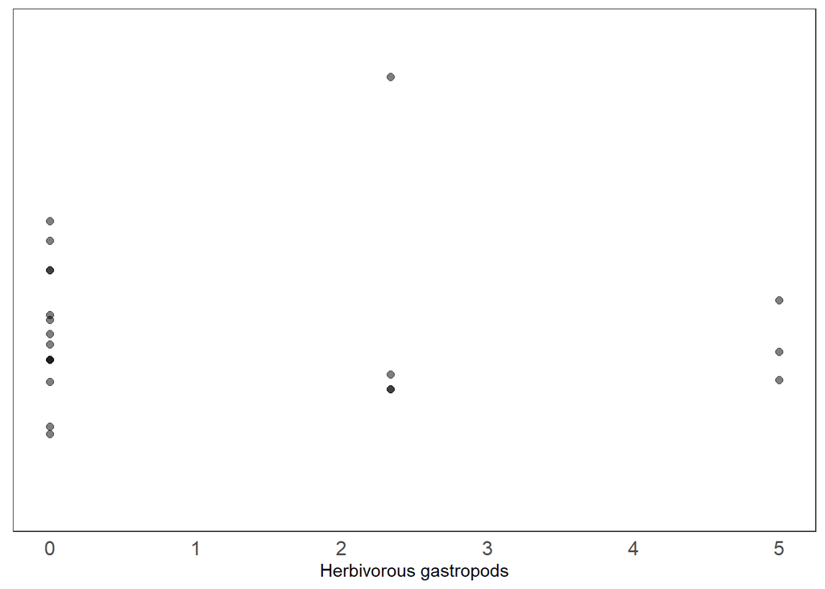

```r
SN_Recl6 <- ggplot() +
   geom_point(data = Rec_l6,                      # adding the raw data (scaled values)
              aes(x = Herbivorous_invert, y = Recruit_size_inside_mat), size= 2, alpha=.5) +
   labs(x = "Herbivorous gastropods", y = expression(sqrt("Total Recruitment"))) +
   Theme1 +
  scale_y_continuous(limits = c(-1, 15), breaks = seq(0,15, by = 3))+
  theme(axis.title.y=element_blank(),
        axis.text.y=element_blank(), axis.title.x=element_text(size = 11))

SN_Recl6
```

3. Abundance of Herbivorous fish

```r
my_lmerOX <- glmmTMB(Recruit_size_inside_mat ~ Mean_Abundance + (1|Site_Code), data=Rec_l6, family = Gamma(link = "log"))
summary(my_lmerOX)
```

```
##  Family: Gamma  ( log )
## Formula:          Recruit_size_inside_mat ~ Mean_Abundance + (1 | Site_Code)
## Data: Rec_l6
##
##      AIC      BIC   logLik deviance df.resid
##    101.7    105.9    -46.9     93.7       17
##
## Random effects:
##
## Conditional model:
##  Groups    Name        Variance  Std.Dev.
##  Site_Code (Intercept) 3.488e-09 5.906e-05
## Number of obs: 21, groups:  Site_Code, 5
##
## Dispersion estimate for Gamma family (sigma^2): 0.237
##
## Conditional model:
##                 Estimate Std. Error z value Pr(>|z|)
## (Intercept)     1.683726   0.212052   7.940 2.02e-15 ***
## Mean_Abundance -0.008883   0.024554  -0.362    0.718
## ---
## Signif. codes:  0 '***' 0.001 '**' 0.01 '*' 0.05 '.' 0.1 ' ' 1
```

```r
r.squaredGLMM(my_lmerOX)
```

```
##                   R2m         R2c
## delta     0.007161798 0.007161813
## lognormal 0.007972551 0.007972568
## trigamma  0.006356918 0.006356931
```

```r
AICc(my_lmerOX)
```

```
## [1] 104.2401
```

```r
check_model(my_lmerOX)
```

```
## `check_outliers()` does not yet support models of class `glmmTMB`.
```

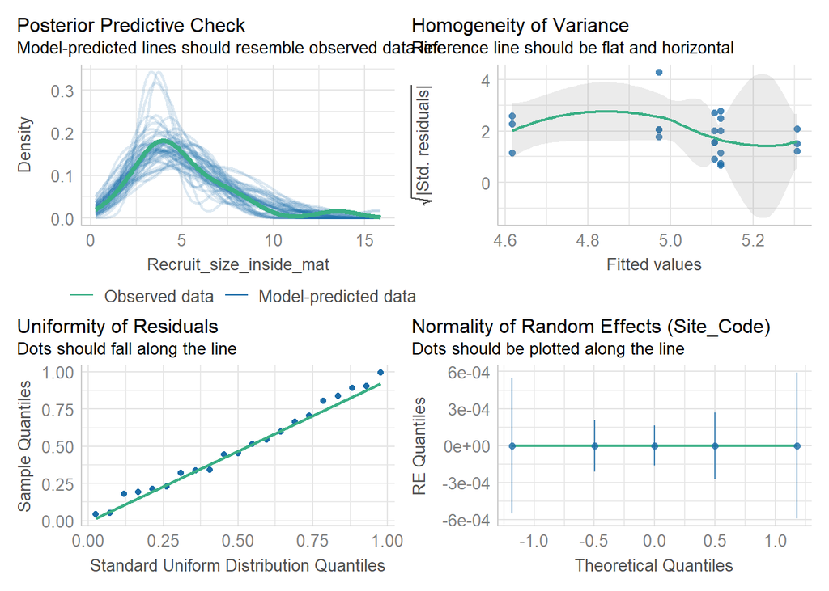

Plot relationship

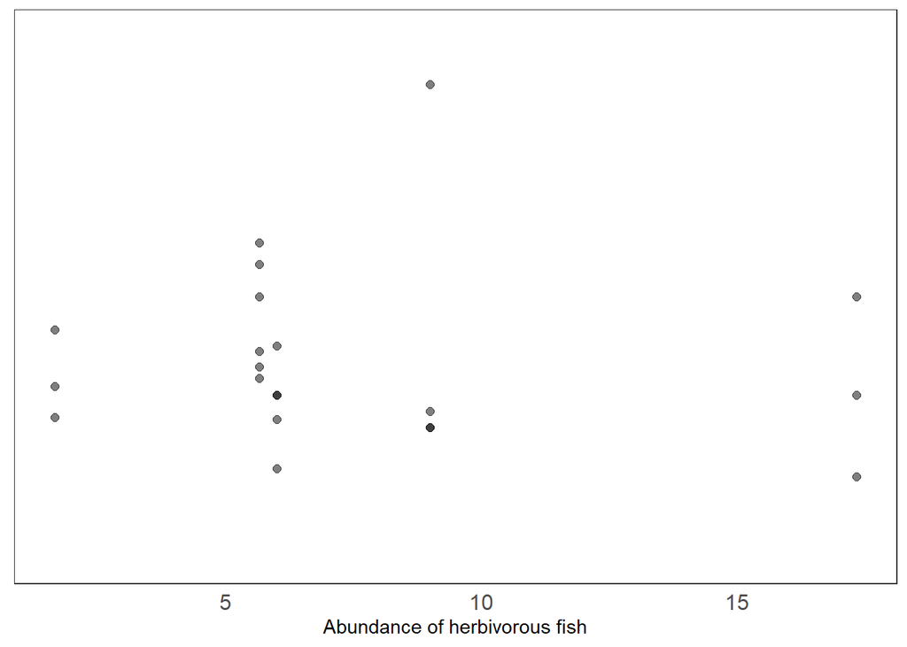

```r
HF_Recl6 <- ggplot() +
   geom_point(data = Rec_l6,                      # adding the raw data (scaled values)
              aes(x = Mean_Abundance, y = Recruit_size_inside_mat), size= 2, alpha=.5) +
   labs(x = "Abundance of herbivorous fish", y = "log(Recruit length)") +
   Theme1 +
  scale_y_continuous(limits = c(-1, 15), breaks = seq(0,15, by = 3))+
  theme(axis.title.y=element_blank(),
        axis.text.y=element_blank(), axis.title.x=element_text(size = 11))

HF_Recl6
```

4. Sargassum

```r
my_lmerOX <- glmmTMB(Recruit_size_inside_mat ~ Sargassum + (1|Site_Code), data=Rec_l6, family = Gamma(link = "log"))
summary(my_lmerOX)
```

```
##  Family: Gamma  ( log )
## Formula:          Recruit_size_inside_mat ~ Sargassum + (1 | Site_Code)
## Data: Rec_l6
##
##      AIC      BIC   logLik deviance df.resid
##    101.9    106.0    -46.9     93.9       17
##
## Random effects:
##
## Conditional model:
##  Groups    Name        Variance  Std.Dev.
##  Site_Code (Intercept) 3.475e-08 0.0001864
## Number of obs: 21, groups:  Site_Code, 5
##
## Dispersion estimate for Gamma family (sigma^2): 0.238
##
## Conditional model:
##              Estimate Std. Error z value Pr(>|z|)
## (Intercept)  1.647322   0.395732   4.163 3.14e-05 ***
## Sargassum   -0.001732   0.022522  -0.077    0.939
## ---
## Signif. codes:  0 '***' 0.001 '**' 0.01 '*' 0.05 '.' 0.1 ' ' 1
```

```r
r.squaredGLMM(my_lmerOX)
```

```
##                    R2m          R2c
## delta     0.0002947024 0.0002948485
## lognormal 0.0003284978 0.0003286606
## trigamma  0.0002612073 0.0002613368
```

```r
AICc(my_lmerOX)
```

```
## [1] 104.3627
```

```r
check_model(my_lmerOX)
```

```
## `check_outliers()` does not yet support models of class `glmmTMB`.
```

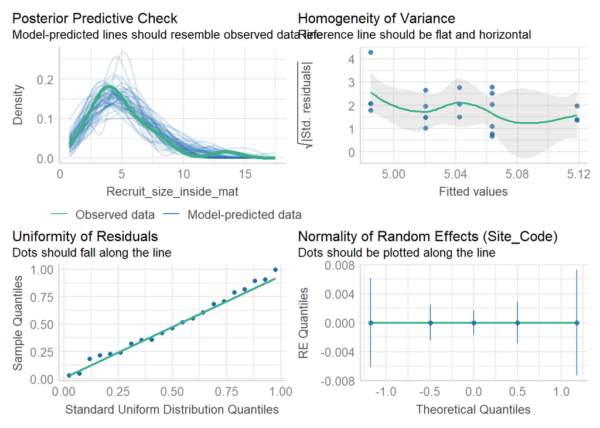

Plot relationship

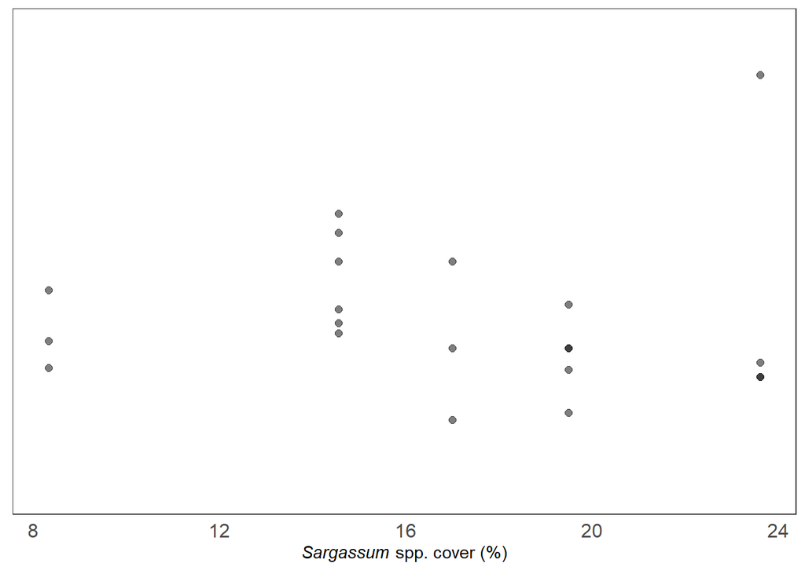

```r
SAR_Recl6 <- ggplot() +
   geom_point(data = Rec_l6,                      # adding the raw data (scaled values)
              aes(x = Sargassum, y = Recruit_size_inside_mat), size= 2, alpha=.5) +
   labs(x = expression(paste(italic("Sargassum"), " spp. cover (%)")), y = "log(Recruit length)") +
   Theme1 +
  scale_y_continuous(limits = c(-1, 15), breaks = seq(0,15, by = 3))+
  theme(axis.title.y=element_blank(),
        axis.text.y=element_blank(), axis.title.x=element_text(size = 11))

SAR_Recl6
```

5. CCA cover

```r
glmm_CCA_l6 <- glmmTMB(Recruit_size_inside_mat ~ Encrusting_macroalgae + (1|Site_Code), data=Rec_l6, family = Gamma(link = "log"))
summary(glmm_CCA_l6)
```

```
##  Family: Gamma  ( log )
## Formula:
## Recruit_size_inside_mat ~ Encrusting_macroalgae + (1 | Site_Code)
## Data: Rec_l6
##
##      AIC      BIC   logLik deviance df.resid
##     98.4    102.6    -45.2     90.4       17
##
## Random effects:
##
## Conditional model:
##  Groups    Name        Variance  Std.Dev.
##  Site_Code (Intercept) 1.434e-10 1.198e-05
## Number of obs: 21, groups:  Site_Code, 5
##
## Dispersion estimate for Gamma family (sigma^2): 0.204
##
## Conditional model:
##                       Estimate Std. Error z value Pr(>|z|)
## (Intercept)            2.01252    0.22898   8.789   <2e-16 ***
## Encrusting_macroalgae -0.01230    0.00616  -1.997   0.0458 *
## ---
## Signif. codes:  0 '***' 0.001 '**' 0.01 '*' 0.05 '.' 0.1 ' ' 1
```

```r
r.squaredGLMM(glmm_CCA_l6)
```

```
##                 R2m       R2c
## delta     0.1618235 0.1618235
## lognormal 0.1750165 0.1750165
## trigamma  0.1482937 0.1482937
```

```r
AICc(glmm_CCA_l6)
```

```
## [1] 100.8955
```

```r
check_model(glmm_CCA_l6)
```

```
## `check_outliers()` does not yet support models of class `glmmTMB`.
```

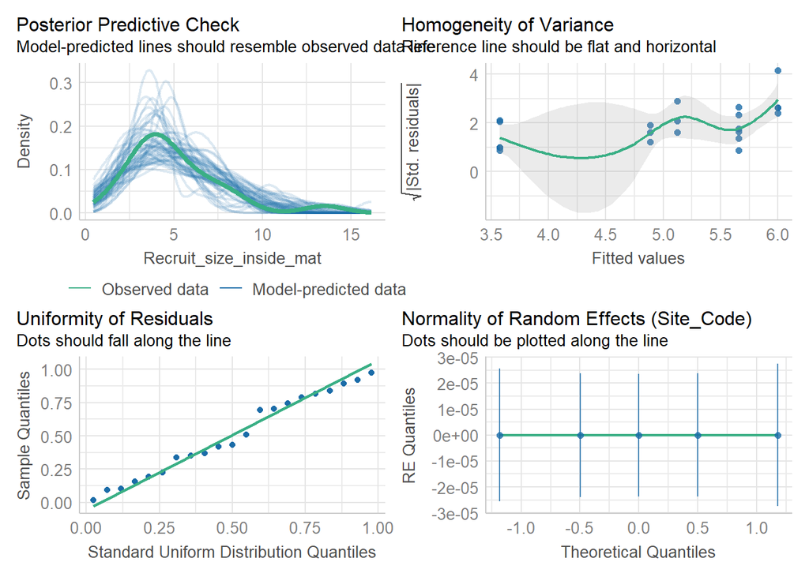

Plot relationship

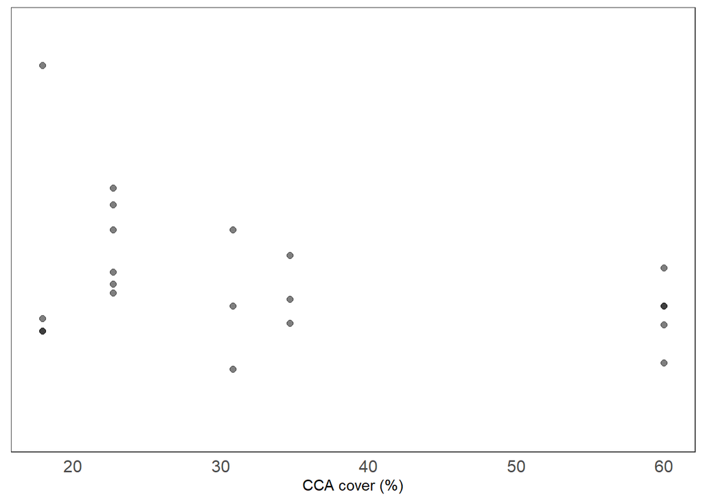

```r
EC_Recl6 <- ggplot() +
   geom_point(data = Rec_l6,                      # adding the raw data (scaled values)
              aes(x = Encrusting_macroalgae, y = Recruit_size_inside_mat), size= 2, alpha=.5) +
   labs(x = "CCA cover (%)", y = "Recruit length (cm))") +
   Theme1 +
  scale_y_continuous(limits = c(-1, 15), breaks = seq(0,15, by = 3))+
  theme(axis.title.y=element_blank(),
        axis.text.y=element_blank(), axis.title.x=element_text(size = 11))

EC_Recl6
```

6. Survival

```r
my_lmerOX <- glmmTMB(Recruit_size_inside_mat ~ Survival_Percentage + (1|Site_Code), data=Rec_l6, family = Gamma(link = "log"))
summary(my_lmerOX)
```

```
##  Family: Gamma  ( log )
## Formula:
## Recruit_size_inside_mat ~ Survival_Percentage + (1 | Site_Code)
## Data: Rec_l6
##
##      AIC      BIC   logLik deviance df.resid
##     98.9    103.0    -45.4     90.9       17
##
## Random effects:
##
## Conditional model:
##  Groups    Name        Variance  Std.Dev.
##  Site_Code (Intercept) 1.168e-10 1.081e-05
## Number of obs: 21, groups:  Site_Code, 5
##
## Dispersion estimate for Gamma family (sigma^2): 0.208
##
## Conditional model:
##                     Estimate Std. Error z value Pr(>|z|)
## (Intercept)          1.15657    0.26563   4.354 1.34e-05 ***
## Survival_Percentage  0.01608    0.00889   1.809   0.0704 .
## ---
## Signif. codes:  0 '***' 0.001 '**' 0.01 '*' 0.05 '.' 0.1 ' ' 1
```

```r
r.squaredGLMM(my_lmerOX)
```

```
##                 R2m       R2c
## delta     0.1328246 0.1328246
## lognormal 0.1442852 0.1442852
## trigamma  0.1211353 0.1211353
```

```r
AICc(my_lmerOX)
```

```
## [1] 101.3608
```

```r
check_model(my_lmerOX)
```

```
## `check_outliers()` does not yet support models of class `glmmTMB`.
```

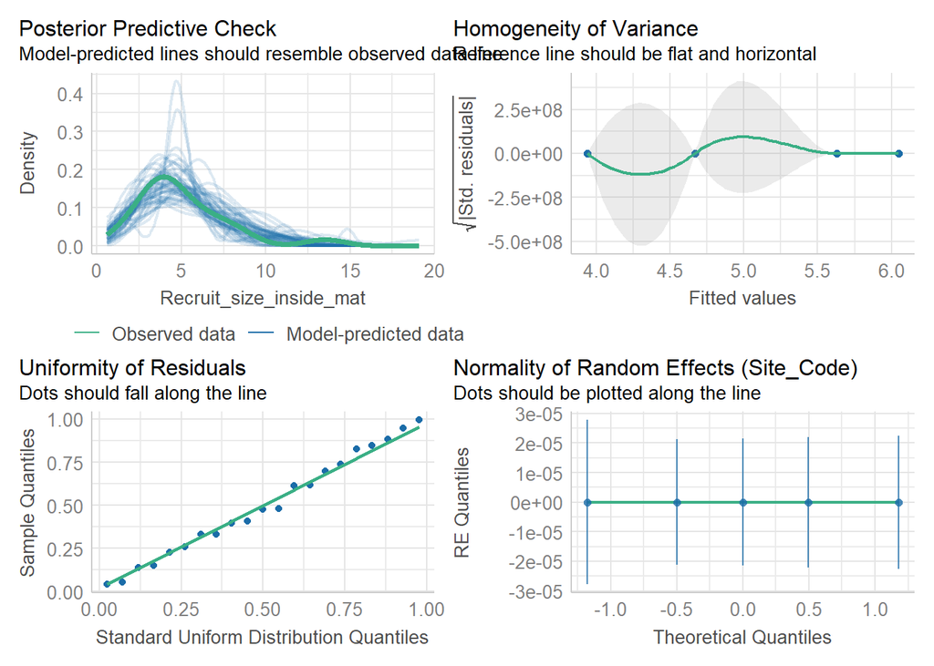

Plot relationship

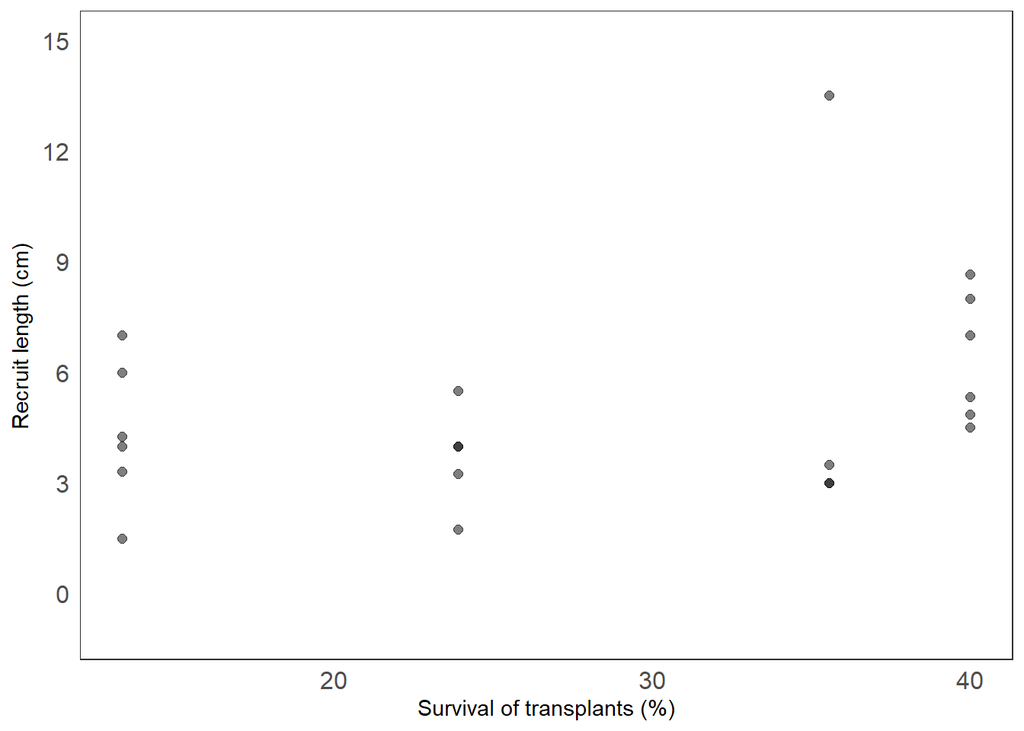

```r
Surv_Recl6 <- ggplot() +
   geom_point(data = Rec_l6,                      # adding the raw data (scaled values)
              aes(x = Survival_Percentage, y = Recruit_size_inside_mat), size= 2, alpha=.5) +
   labs(x = "Survival of transplants (%)", y =  expression("Recruit length (cm)")) +
   Theme1 +
  scale_y_continuous(limits = c(-1, 15), breaks = seq(0,15, by = 3)) +
  theme(axis.title.x=element_text(size = 11), axis.title.y=element_text(size = 11))


Surv_Recl6
```

7. Grazing

```r
my_lmerOX <- glmmTMB(Recruit_size_inside_mat ~ Mean_Grazing + (1|Site_Code), data=Rec_l6, family = Gamma(link = "log"))
summary(my_lmerOX)
```

```
##  Family: Gamma  ( log )
## Formula:          Recruit_size_inside_mat ~ Mean_Grazing + (1 | Site_Code)
## Data: Rec_l6
##
##      AIC      BIC   logLik deviance df.resid
##     99.7    103.9    -45.8     91.7       17
##
## Random effects:
##
## Conditional model:
##  Groups    Name        Variance  Std.Dev.
##  Site_Code (Intercept) 1.886e-10 1.373e-05
## Number of obs: 21, groups:  Site_Code, 5
##
## Dispersion estimate for Gamma family (sigma^2): 0.216
##
## Conditional model:
##              Estimate Std. Error z value Pr(>|z|)
## (Intercept)   1.95140    0.25003   7.805 5.97e-15 ***
## Mean_Grazing -0.13009    0.08615  -1.510    0.131
## ---
## Signif. codes:  0 '***' 0.001 '**' 0.01 '*' 0.05 '.' 0.1 ' ' 1
```

```r
r.squaredGLMM(my_lmerOX)
```

```
##                  R2m        R2c
## delta     0.10463161 0.10463161
## lognormal 0.11432010 0.11432010
## trigamma  0.09480324 0.09480325
```

```r
AICc(my_lmerOX)
```

```
## [1] 102.1992
```

```r
check_model(my_lmerOX)
```

```
## `check_outliers()` does not yet support models of class `glmmTMB`.
```

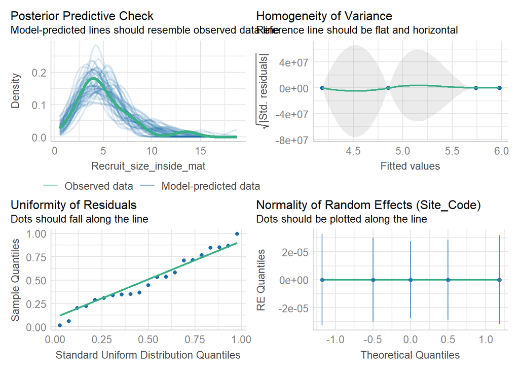

Plot relationship

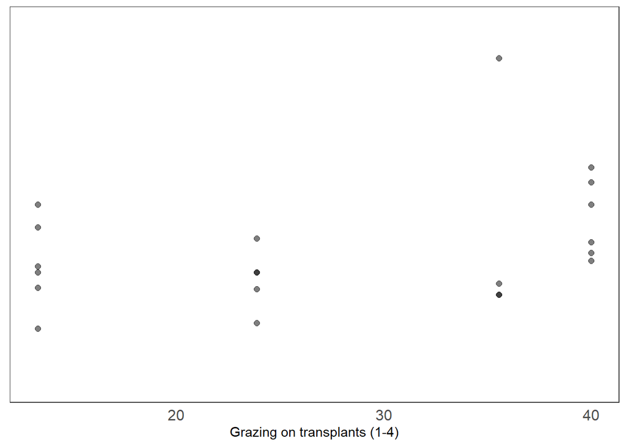

```r
Gr_Recl6 <- ggplot() +
   geom_point(data = Rec_l6,                      # adding the raw data (scaled values)
              aes(x = Survival_Percentage, y = Recruit_size_inside_mat), size= 2, alpha=.5) +
   labs(x = "Grazing on transplants (1-4)", y =  expression(sqrt("Total Recruitment"))) +
   Theme1 +
  scale_y_continuous(limits = c(-1, 15), breaks = seq(0,15, by = 3)) +
    theme(axis.title.y=element_blank(),
        axis.text.y=element_blank(), axis.title.x=element_text(size = 11))


Gr_Recl6
```

8. Fouling

```r
my_lmerOX <- glmmTMB(Recruit_size_inside_mat ~ Percentage_fouling + (1|Site_Code), data=Rec_l6, family = Gamma(link = "log"))
summary(my_lmerOX)
```

```
##  Family: Gamma  ( log )
## Formula:
## Recruit_size_inside_mat ~ Percentage_fouling + (1 | Site_Code)
## Data: Rec_l6
##
##      AIC      BIC   logLik deviance df.resid
##    100.6    104.8    -46.3     92.6       17
##
## Random effects:
##
## Conditional model:
##  Groups    Name        Variance Std.Dev.
##  Site_Code (Intercept) 3.2e-10  1.789e-05
## Number of obs: 21, groups:  Site_Code, 5
##
## Dispersion estimate for Gamma family (sigma^2): 0.225
##
## Conditional model:
##                     Estimate Std. Error z value Pr(>|z|)
## (Intercept)         1.791884   0.191122   9.376   <2e-16 ***
## Percentage_fouling -0.006715   0.005971  -1.125    0.261
## ---
## Signif. codes:  0 '***' 0.001 '**' 0.01 '*' 0.05 '.' 0.1 ' ' 1
```

```r
r.squaredGLMM(my_lmerOX)
```

```
##                  R2m        R2c
## delta     0.05917492 0.05917492
## lognormal 0.06519819 0.06519819
## trigamma  0.05312305 0.05312305
```

```r
AICc(my_lmerOX)
```

```
## [1] 103.1448
```

```r
check_model(my_lmerOX)
```

```
## `check_outliers()` does not yet support models of class `glmmTMB`.
```

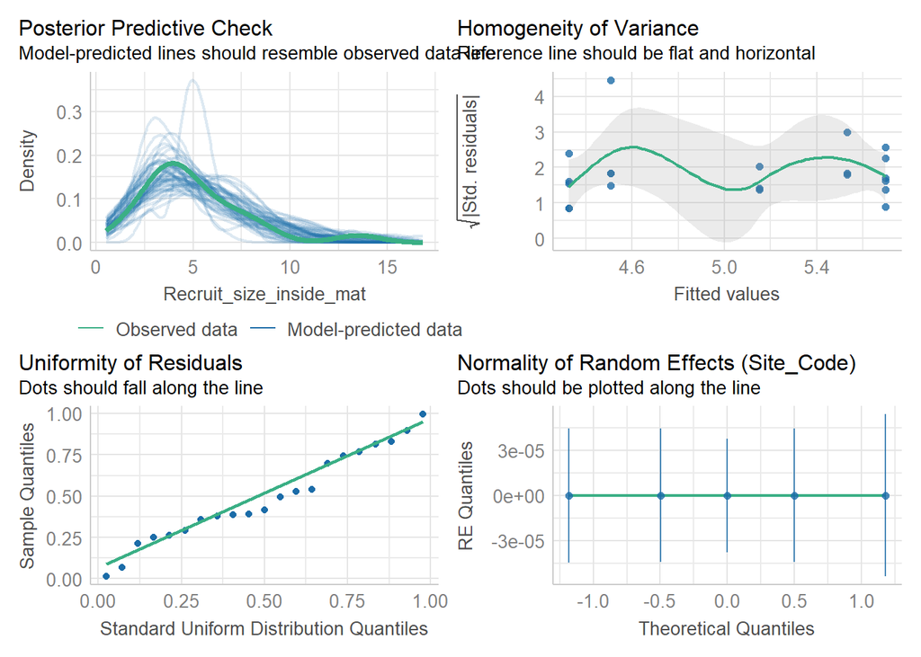

Plot relationship

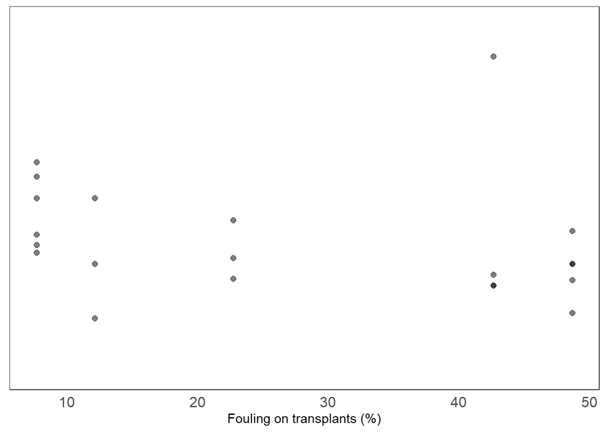

```r
Fo_Recl6 <- ggplot() +
   geom_point(data = Rec_l6,                      # adding the raw data (scaled values)
              aes(x = Percentage_fouling, y = Recruit_size_inside_mat), size= 2, alpha=.5) +
   labs(x = "Fouling on transplants (%)", y =  expression(sqrt("Total Recruitment"))) +
   Theme1 +
  scale_y_continuous(limits = c(-1, 15), breaks = seq(0,15, by = 3)) +
    theme(axis.title.y=element_blank(),
        axis.text.y=element_blank(), axis.title.x=element_text(size = 11))


Fo_Recl6
```

9. Mean Intensity

```r
glmm_T<- glmmTMB(Recruit_size_inside_mat ~ Mean_Intensity + (1|Site_Code), data=Rec_l6, family = Gamma(link = "log"))
summary(glmm_T)
```

```
##  Family: Gamma  ( log )
## Formula:          Recruit_size_inside_mat ~ Mean_Intensity + (1 | Site_Code)
## Data: Rec_l6
##
##      AIC      BIC   logLik deviance df.resid
##    101.7    105.9    -46.9     93.7       17
##
## Random effects:
##
## Conditional model:
##  Groups    Name        Variance Std.Dev.
##  Site_Code (Intercept) 0.002312 0.04808
## Number of obs: 21, groups:  Site_Code, 5
##
## Dispersion estimate for Gamma family (sigma^2): 0.234
##
## Conditional model:
##                  Estimate Std. Error z value Pr(>|z|)
## (Intercept)     1.909e+00  8.002e-01   2.385   0.0171 *
## Mean_Intensity -2.894e-05  7.879e-05  -0.367   0.7134
## ---
## Signif. codes:  0 '***' 0.001 '**' 0.01 '*' 0.05 '.' 0.1 ' ' 1
```

```r
r.squaredGLMM(glmm_T)
```

```
##                   R2m        R2c
## delta     0.007131515 0.01682866
## lognormal 0.007922842 0.01869601
## trigamma  0.006344092 0.01497053
```

```r
AICc(glmm_T)
```

```
## [1] 104.2281
```

```r
check_model(glmm_T)
```

```
## `check_outliers()` does not yet support models of class `glmmTMB`.
```

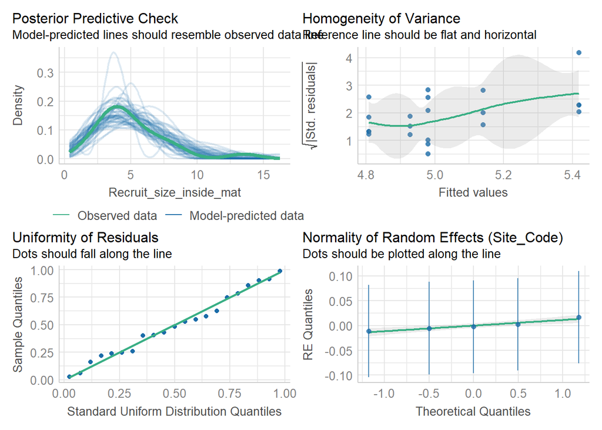

Plot relationship

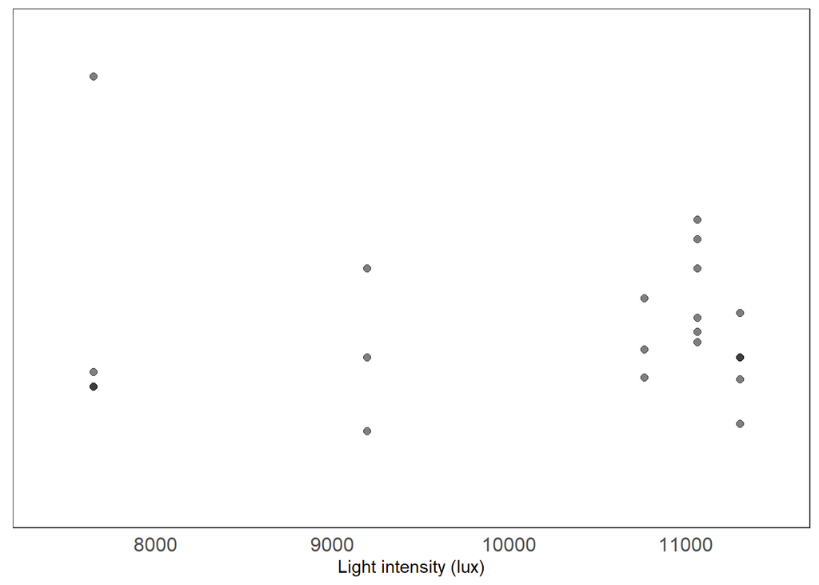

```r
T_Recl6 <- ggplot() +
   geom_point(data = Rec_l6,                      # adding the raw data (scaled values)
              aes(x = Mean_Intensity, y = Recruit_size_inside_mat), size= 2, alpha=.5) +
   labs(x = "Light intensity (lux)", y = "log(Recruit length + 1)") +
   Theme1 +
  scale_y_continuous(limits = c(-1, 15), breaks = seq(0,15, by = 3))+
  scale_x_continuous(limits = c(7400, 11500), breaks = seq(8000,11000, by = 1000))+
  theme(axis.title.y=element_blank(),
        axis.text.y=element_blank(), axis.title.x=element_text(size = 11))

T_Recl6
```

10. Daily SD

```r
glmm_SD<- glmmTMB(Recruit_size_inside_mat ~ Mean_SD + (1|Site_Code), data=Rec_l6, family = Gamma(link = "log"))
summary(glmm_SD)
```

```
##  Family: Gamma  ( log )
## Formula:          Recruit_size_inside_mat ~ Mean_SD + (1 | Site_Code)
## Data: Rec_l6
##
##      AIC      BIC   logLik deviance df.resid
##    100.7    104.8    -46.3     92.7       17
##
## Random effects:
##
## Conditional model:
##  Groups    Name        Variance  Std.Dev.
##  Site_Code (Intercept) 2.733e-10 1.653e-05
## Number of obs: 21, groups:  Site_Code, 5
##
## Dispersion estimate for Gamma family (sigma^2): 0.226
##
## Conditional model:
##             Estimate Std. Error z value Pr(>|z|)
## (Intercept)   1.3297     0.2745   4.845 1.27e-06 ***
## Mean_SD      10.6909     9.6434   1.109    0.268
## ---
## Signif. codes:  0 '***' 0.001 '**' 0.01 '*' 0.05 '.' 0.1 ' ' 1
```

```r
r.squaredGLMM(glmm_SD)
```

```
##                  R2m        R2c
## delta     0.06112937 0.06112937
## lognormal 0.06734231 0.06734231
## trigamma  0.05488429 0.05488429
```

```r
AICc(glmm_SD)
```

```
## [1] 103.1636
```

```r
check_model(glmm_SD)
```

```
## `check_outliers()` does not yet support models of class `glmmTMB`.
```

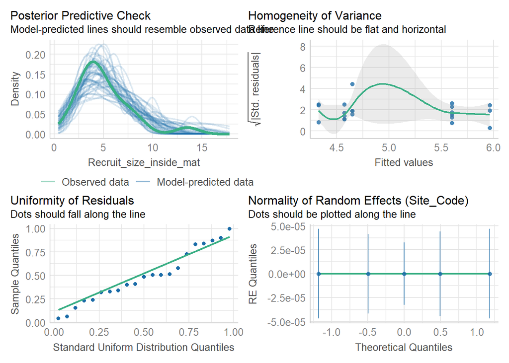

Plot relationship

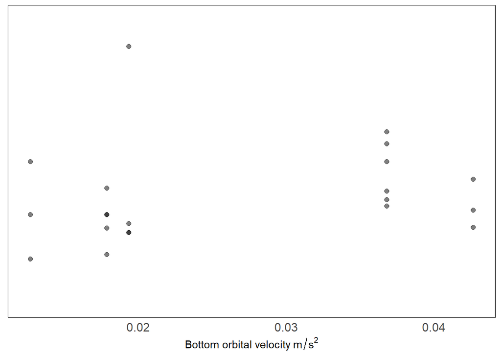

```r
SD_Recl6 <- ggplot() +
   geom_point(data = Rec_l6,                      # adding the raw data (scaled values)
              aes(x = Mean_SD, y = Recruit_size_inside_mat), size= 2, alpha=.5) +
   labs(x = expression ("Bottom orbital velocity"~m/s^2), y = "log(Recruit length + 1)") +
   Theme1 +
  scale_y_continuous(limits = c(-1, 15), breaks = seq(0,15, by = 3))+
    theme(axis.title.y=element_blank(),
        axis.text.y=element_blank(), axis.title.x=element_text(size = 11))

SD_Recl6
```

11. Create supplementary Figure 3

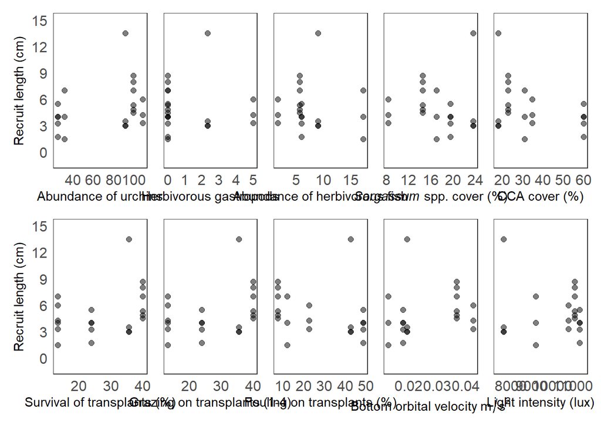

```r
U_Recl6 + SN_Recl6 + HF_Recl6 + SAR_Recl6 + EC_Recl6 + Surv_Recl6 + Gr_Recl6 + Fo_Recl6+ SD_Recl6 + T_Recl6 + plot_layout(ncol=5)
```

```r
ggsave("Rl6_predictors.jpeg", width = 30, height = 15, units = "cm")
```

### **5d)** Recruit length 9 months

1. Abundance of urchins

```r
my_lmerOX <- glmmTMB(Recruit_size_inside_mat ~ Urchin + (1|Site_Code), data=Rec_l9, family = gaussian())
summary(my_lmerOX)
```

```
##  Family: gaussian  ( identity )
## Formula:          Recruit_size_inside_mat ~ Urchin + (1 | Site_Code)
## Data: Rec_l9
##
##      AIC      BIC   logLik deviance df.resid
##     88.5     91.8    -40.2     80.5       13
##
## Random effects:
##
## Conditional model:
##  Groups    Name        Variance Std.Dev.
##  Site_Code (Intercept) 2.594    1.610
##  Residual              5.084    2.255
## Number of obs: 17, groups:  Site_Code, 4
##
## Dispersion estimate for gaussian family (sigma^2): 5.08
##
## Conditional model:
##             Estimate Std. Error z value Pr(>|z|)
## (Intercept)  4.26270    2.73991   1.556    0.120
## Urchin       0.04620    0.03076   1.502    0.133
```

```r
r.squaredGLMM(my_lmerOX)
```

```
##            R2m       R2c
## [1,] 0.1998099 0.4701103
```

```r
AICc(my_lmerOX)
```

```
## [1] 91.79659
```

```r
check_model(my_lmerOX)
```

```
## `check_outliers()` does not yet support models of class `glmmTMB`.
```

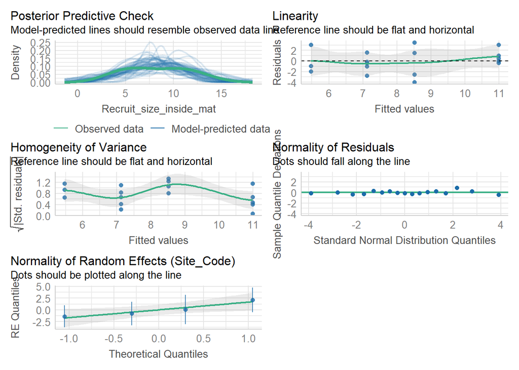

Plot relationship

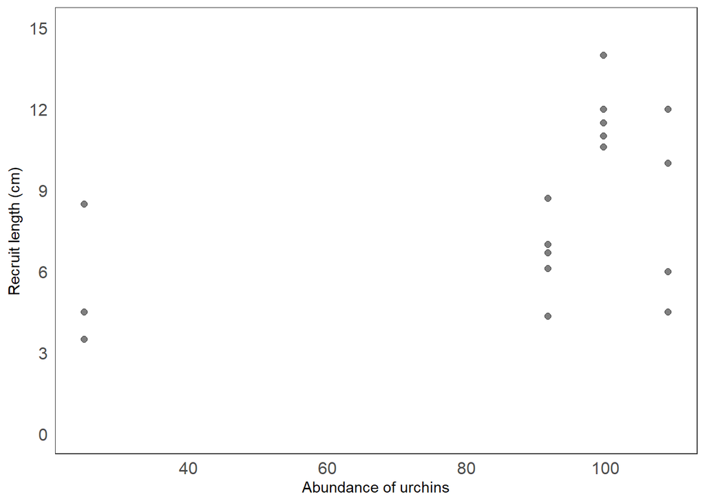

```r
U_Recl9 <- ggplot() +
   geom_point(data = Rec_l9,                      # adding the raw data (scaled values)
              aes(x = Urchin, y = Recruit_size_inside_mat), size= 2, alpha=.5) +
   labs(x = "Abundance of urchins", y = expression("Recruit length (cm)")) +
   Theme1 +
  scale_y_continuous(limits = c(0, 15), breaks = seq(0,15, by = 3)) +
  theme(axis.title.x=element_text(size = 11), axis.title.y=element_text(size = 11))

U_Recl9
```

2. Abundance of gastropods

```r
my_lmerOX <- glmmTMB(Recruit_size_inside_mat ~ Herbivorous_invert + (1|Site_Code), data=Rec_l9, family = gaussian())
summary(my_lmerOX)
```

```
##  Family: gaussian  ( identity )
## Formula:
## Recruit_size_inside_mat ~ Herbivorous_invert + (1 | Site_Code)
## Data: Rec_l9
##
##      AIC      BIC   logLik deviance df.resid
##     90.2     93.5    -41.1     82.2       13
##
## Random effects:
##
## Conditional model:
##  Groups    Name        Variance Std.Dev.
##  Site_Code (Intercept) 4.330    2.081
##  Residual              5.166    2.273
## Number of obs: 17, groups:  Site_Code, 4
##
## Dispersion estimate for gaussian family (sigma^2): 5.17
##
## Conditional model:
##                    Estimate Std. Error z value Pr(>|z|)
## (Intercept)          8.4529     1.5960   5.296 1.18e-07 ***
## Herbivorous_invert  -0.2032     0.5771  -0.352    0.725
## ---
## Signif. codes:  0 '***' 0.001 '**' 0.01 '*' 0.05 '.' 0.1 ' ' 1
```

```r
r.squaredGLMM(my_lmerOX)
```

```
##             R2m      R2c
## [1,] 0.01820707 0.465882
```

```r
AICc(my_lmerOX)
```

```
## [1] 93.51386
```

```r
check_model(my_lmerOX)
```

```
## `check_outliers()` does not yet support models of class `glmmTMB`.
```

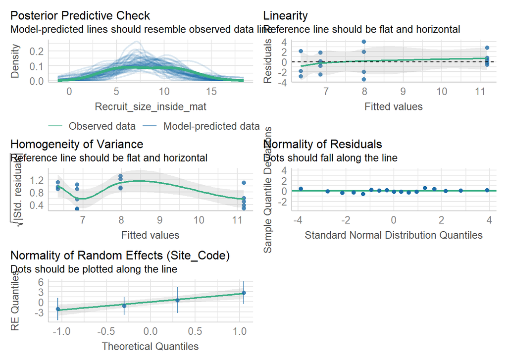

Plot relationship

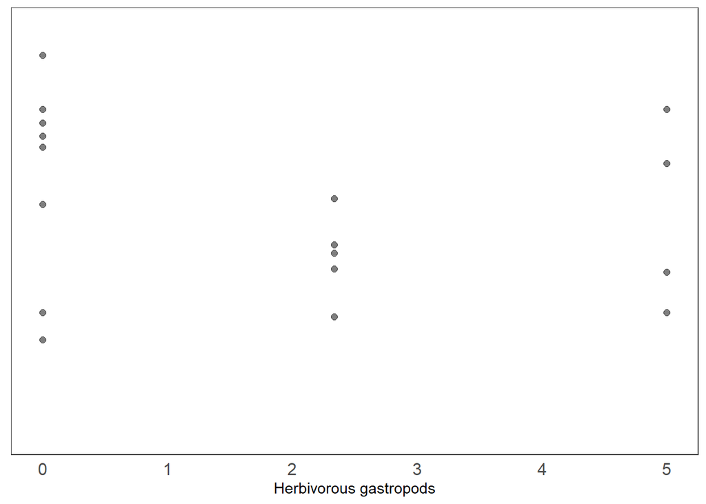

```r
SN_Recl9 <- ggplot() +
   geom_point(data = Rec_l9,                      # adding the raw data (scaled values)
              aes(x = Herbivorous_invert, y = Recruit_size_inside_mat), size= 2, alpha=.5) +
   labs(x = "Herbivorous gastropods", y = "log(Recruit length)") +
   Theme1 +
  scale_y_continuous(limits = c(0, 15), breaks = seq(0,15, by = 3))+
  theme(axis.title.y=element_blank(),
        axis.text.y=element_blank(), axis.title.x=element_text(size = 11))

SN_Recl9
```

3. Abundance of herbivorous fish

```r
glmm_HF<- glmmTMB(Recruit_size_inside_mat ~ Mean_Abundance + (1|Site_Code), data=Rec_l9, family = gaussian())
summary(glmm_HF)
```

```
##  Family: gaussian  ( identity )
## Formula:          Recruit_size_inside_mat ~ Mean_Abundance + (1 | Site_Code)
## Data: Rec_l9
##
##      AIC      BIC   logLik deviance df.resid
##     90.1     93.4    -41.0     82.1       13
##
## Random effects:
##
## Conditional model:
##  Groups    Name        Variance Std.Dev.
##  Site_Code (Intercept) 4.219    2.054
##  Residual              5.149    2.269
## Number of obs: 17, groups:  Site_Code, 4
##
## Dispersion estimate for gaussian family (sigma^2): 5.15
##
## Conditional model:
##                Estimate Std. Error z value Pr(>|z|)
## (Intercept)      9.3440     2.7633   3.381 0.000721 ***
## Mean_Abundance  -0.2253     0.4454  -0.506 0.613029
## ---
## Signif. codes:  0 '***' 0.001 '**' 0.01 '*' 0.05 '.' 0.1 ' ' 1
```

```r
r.squaredGLMM(glmm_HF)
```

```
##             R2m       R2c
## [1,] 0.03896133 0.4717666
```

```r
AICc(glmm_HF)
```

```
## [1] 93.38693
```

```r
check_model(glmm_HF)
```

```
## `check_outliers()` does not yet support models of class `glmmTMB`.
```

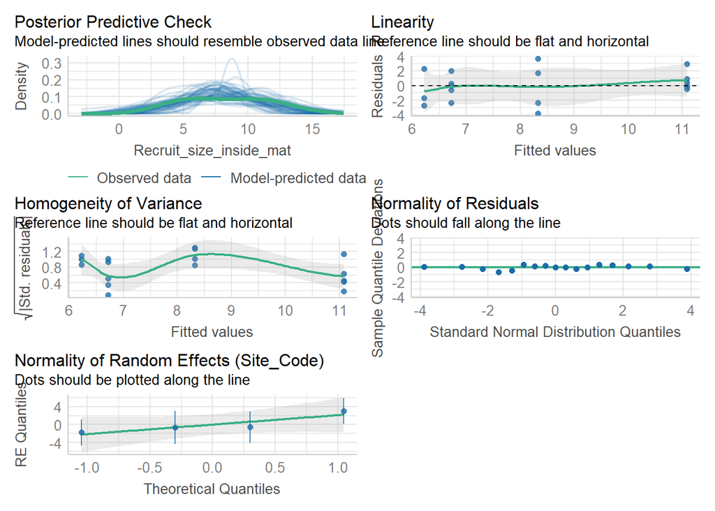

Plot relationship

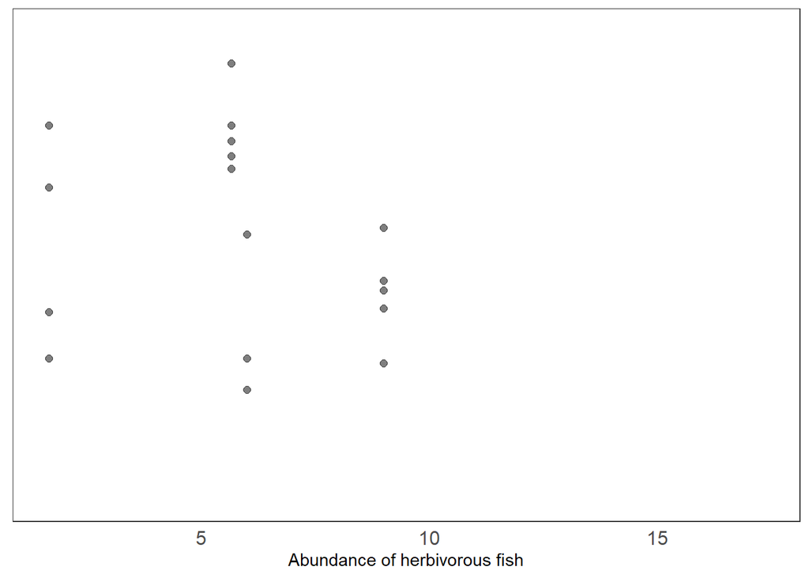

```r
HFplot <- ggplot()  +
   geom_point(data = Rec_l9,                      # adding the raw data (scaled values)
              aes(x = Mean_Abundance, y = Recruit_size_inside_mat), size= 2, alpha=.5) +
   labs(x = "Abundance of herbivorous fish", y = "log(Recruit length + 1)") +
   Theme1 +
  scale_y_continuous(limits = c(0, 15), breaks = seq(0,15, by = 3)) +
  theme(axis.title.y=element_blank(),
        axis.text.y=element_blank(), axis.title.x=element_text(size = 11))

HFplot
```

4. Sargassum cover

```r
my_lmerOX <- glmmTMB(Recruit_size_inside_mat ~ Sargassum + (1|Site_Code), data=Rec_l9, family = gaussian())
summary(my_lmerOX)
```

```
##  Family: gaussian  ( identity )
## Formula:          Recruit_size_inside_mat ~ Sargassum + (1 | Site_Code)
## Data: Rec_l9
##
##      AIC      BIC   logLik deviance df.resid
##     89.3     92.6    -40.6     81.3       13
##
## Random effects:
##
## Conditional model:
##  Groups    Name        Variance Std.Dev.
##  Site_Code (Intercept) 3.281    1.811
##  Residual              5.142    2.268
## Number of obs: 17, groups:  Site_Code, 4
##
## Dispersion estimate for gaussian family (sigma^2): 5.14
##
## Conditional model:
##             Estimate Std. Error z value Pr(>|z|)
## (Intercept)  11.3922     3.2452   3.510 0.000447 ***
## Sargassum    -0.1998     0.1856  -1.076 0.281711
## ---
## Signif. codes:  0 '***' 0.001 '**' 0.01 '*' 0.05 '.' 0.1 ' ' 1
```

```r
r.squaredGLMM(my_lmerOX)
```

```
##            R2m       R2c
## [1,] 0.1434673 0.4771106
```

```r
AICc(my_lmerOX)
```

```
## [1] 92.61635
```

```r
check_model(my_lmerOX)
```

```
## `check_outliers()` does not yet support models of class `glmmTMB`.
```

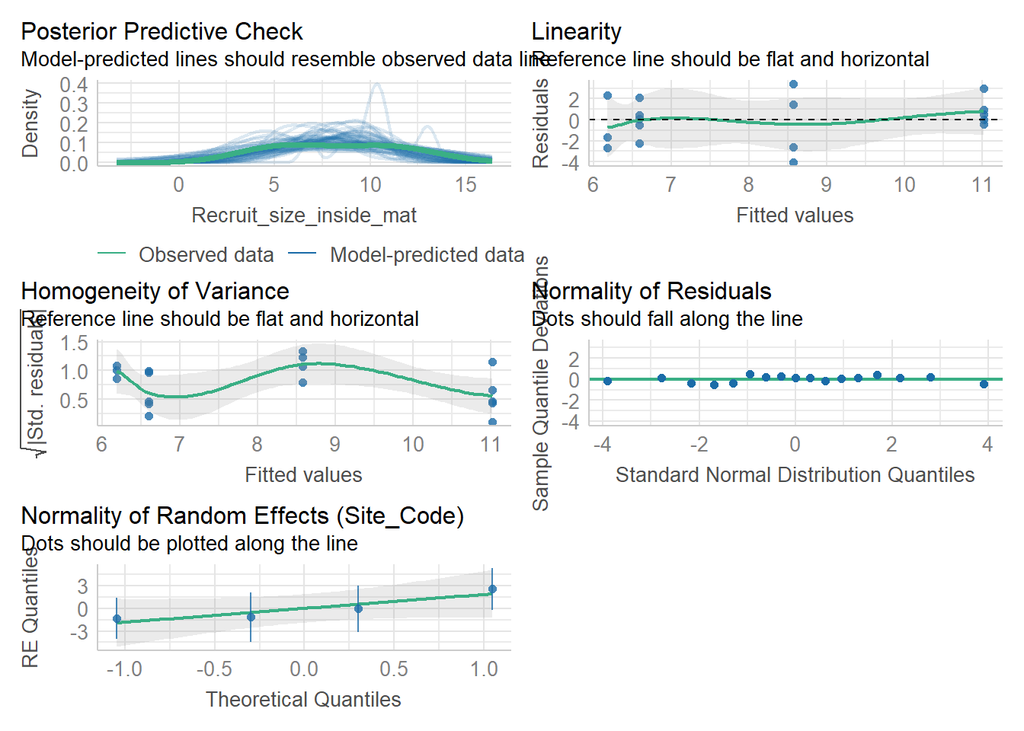

Plot relationship

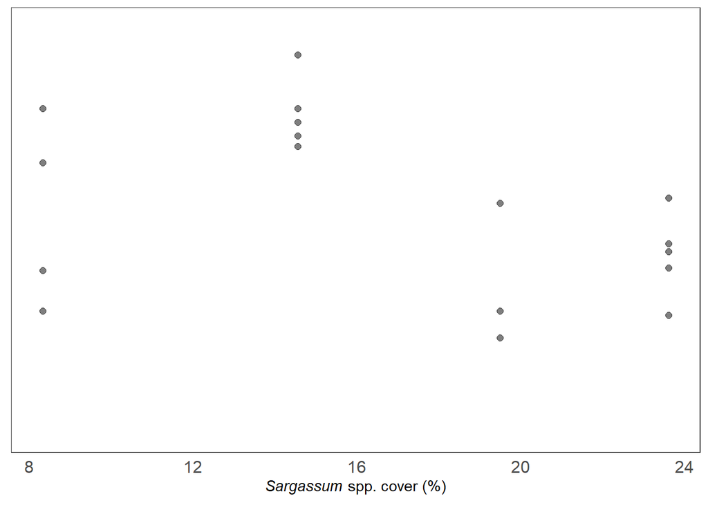

```r
SAR_Recl9 <- ggplot() +
   geom_point(data = Rec_l9,                      # adding the raw data (scaled values)
              aes(x = Sargassum, y = Recruit_size_inside_mat), size= 2, alpha=.5) +
   labs(x = expression(paste(italic("Sargassum"), " spp. cover (%)")), y = "log(Recruit length)") +
   Theme1 +
  scale_y_continuous(limits = c(0, 15), breaks = seq(0,15, by = 3))+
    theme(axis.title.y=element_blank(),
        axis.text.y=element_blank(), axis.title.x=element_text(size = 11))

SAR_Recl9
```

5. CCA cover

```r
my_lmerOX <- glmmTMB(Recruit_size_inside_mat ~ Encrusting_macroalgae + (1|Site_Code), data=Rec_l9, gaussian())
summary(my_lmerOX)
```

```
##  Family: gaussian  ( identity )
## Formula:
## Recruit_size_inside_mat ~ Encrusting_macroalgae + (1 | Site_Code)
## Data: Rec_l9
##
##      AIC      BIC   logLik deviance df.resid
##     89.1     92.4    -40.5     81.1       13
##
## Random effects:
##
## Conditional model:
##  Groups    Name        Variance Std.Dev.
##  Site_Code (Intercept) 3.195    1.787
##  Residual              5.089    2.256
## Number of obs: 17, groups:  Site_Code, 4
##
## Dispersion estimate for gaussian family (sigma^2): 5.09
##
## Conditional model:
##                       Estimate Std. Error z value Pr(>|z|)
## (Intercept)           10.67474    2.41484   4.420 9.85e-06 ***
## Encrusting_macroalgae -0.07854    0.06615  -1.187    0.235
## ---
## Signif. codes:  0 '***' 0.001 '**' 0.01 '*' 0.05 '.' 0.1 ' ' 1
```

```r
r.squaredGLMM(my_lmerOX)
```

```
##           R2m       R2c
## [1,] 0.149346 0.4774541
```